# 量的調査（第5回）

Author

藤原翔

Published

October 26, 2023

調査のデータを用い，われわれは学歴別の生活満足度や婚姻状態と収入の関連をみる．ここから学歴や婚姻状態によって差があることを確認するが，この差を適切に読み取り，解釈できているのだろうか．

- 学歴によって生活満足度が異なる．つまり，それは学歴によって生活満足度が異なるのである（何も解釈できていないが正しい）．
- 学歴によって生活満足度が異なる．つまり，学歴は生活満足度に影響を与えているあるいは生活満足度に学歴は効果を持つ（関連は因果によって生じている）．
- 学歴によって生活満足度が異なる．それは，学歴は生活満足度に影響を与えているからかもしれないし，そもそも高い学歴を得る人は生活満足度が高いのかもしれない（関連は因果によって生じている部分とそうでない部分によって生じる部分がある）．

# 1 因果を定義する

計量分析を学んでいると因果（causality），効果（effect） ，影響（affect），インパクト（impact）といった様々な言葉が用いられている．

そもそも社会調査データで明らかになるのは変数間の関連（関連ですらうまく捉えられているかは怪しい）だが，なぜ影響や効果といった言葉を用いるのだろうか．因果効果の正確な定義とはどのように可能だろうか．

因果推論で重要なのは観察データに対して回帰モデルを適用するといった方法からいったん距離をおくということである．回帰モデルの係数から因果を考えないことがポイントになる．最終的には回帰モデルを用いるがそれはあくまで推定のためのツールであり，因果を考えること（推論）と回帰モデルによる推定は分けて考える必要がある．

## 1.1 推定対象（estimand）

因果効果を考える場合であっても，関連を見たい場合であっても，そもそも明らかにしたい値は何か，つまりestimandを明確にする必要がある．estimandは調査研究における対象であり，その推論のために我々はデータを収集する．推定の対象となるestimandは何か (Lundberg, Johnson, and Stewart 2021)，それを明らかにした上で計量分析を行う必要がある．

## 1.2 対象となる集団（target population）

どの集団についての因果効果を推定したいのかを明らかにする必要がある．

## 1.3 ポテンシャルアウトカム (potential outcomes)

個人$i$が実際に処置を受けたかどうかを示す処置変数（treatment variable）を$A_i$とし，$A_i=1$の場合は処置を受け，$A_i=0$の場合は処置を受けなかったとする．$A_i$は$1$か$0$の値をとるダミー変数である．大学進学を処置と考えれば，個人$i$が大学進学していたら$A_i=1$，非進学である場合は$A_i=0$となる．

この設定の場合，それぞれの個人には2つの潜在的なアウトカムがある．個人$i$が処置（treatment）を受けた場合（$a=1$）のアウトカムの値を$Y_i^{a=1}$，処置を受けなかった場合（$a=0$）のアウトカムの値を$Y_i^{a=0}$とする．これはポテンシャル（潜在，潜在的）アウトカム（potential outcomes），潜在的反応（potential response），反実仮想アウトカム（counterfactual outcomes）などと呼ばれる．例えば個人$i$の大学進学と収入について，もし大学進学していればその収入は$Y_i^{a=1}$，非進学であればその収入は$Y_i^{a=0}$となる．$A$は確率変数であり、$a$はその確率変数の特定の値あるいは実現値である．

また，個体$i$について調査や実験によって実際に観察されたアウトカム（outcome）を$Y_i$とする． 観察される変数は実際に処置を受けたかどうかを示す$A_i$や実際のアウトカムである$Y_i$であり，$Y_i^1$や$Y_i^0$は観察できない．

まず観察される$Y_i$，$A_i$と観察されない$Y_i^{a=1}$と$Y_i^{a=0}$を区別できるようにする．そして，$Y_i^{a=1}$と$Y_i^{a=0}$から理論的な推定対象を設定する．$Y_i$や$A_i$はこの推定対象の値をデータから近似するために用いられるだけであり，因果効果の定義そのものには基本的には用いられない．

## 1.4 個人レベルでの処置効果

個人（あるいは個体）$i$についての処置効果（individual treatment effect）あるいは因果効果（individual causal effect）を$\tau_i$とする．

$$\tau_i = Y_i^{a=1} - Y_i^{a=0}.$$

次のように$a=$が省略されて表記されることもあり，この資料でもしばしば省略する．

$$\tau_i = Y_i^1 - Y_i^0.$$

また$()$を使ってポテンシャルアウトカムを表す場合もある．

$$\tau_i = Y_i(1) - Y_i(0).$$

例えば，$i=1$の個人について，$Y_1(1)=Y_1(0)$，つまり$Y_1(1) - Y_1(0) = 0$であれば因果効果はなく，$Y_1(1)\neq Y_1(0)$つまり$Y_1(1)-Y_1(0)\neq 0$であれば因果効果があるといえる． 因果効果の定義は非常にシンプルであり，そこには回帰モデルも実験も出てこない．

次のような例を考えてみよう．ここではポテンシャルアウトカムがすべて分かっているものとする（現実にはありえない）．$i=1$については因果効果は$\tau_1=1-2=-1$となり，マイナスの効果がある．$i=2$については因果効果は$\tau_2=2-1=1$となりプラスの因果効果．$i=3$については因果効果は$\tau_3=3-3=0$となり因果効果はない．

| $i$ | $Y_i^{a=1}$ | $Y_i^{a=0}$ | $\tau_i$ |
| --- | --- | --- | --- |
| 1 | 1 | 2 | -1 |
| 2 | 2 | 1 | 1 |
| 3 | 3 | 3 | 0 |
| 4 | 5 | 3 | 2 |
| 5 | 4 | 5 | -1 |

実際には$Y_i^{a=1}$も$Y_i^{a=0}$は理論的な値であり，両者について直接データが得られるわけではないため，個人レベルでの因果効果をデータから直接求めることはできない．だが，もしポテンシャルアウトカムが両方明らかになれば因果効果は極めて簡単な計算から求めることができる．因果効果の定義はとても単純なのである．

例えば，ポテンシャルアウトカムのうちのひとつは実際には観察されるかもしれない．つまり$A_i=1$の個人$i$については観察されたアウトカムである$Y_i$は$Y_i^{a=1}$となるかもしれない．また，$A_i=0$の個人$i$については観察されたアウトカムである$Y_i$は$Y_i^{a=0}$となるかもしれない．そこで，$A = a$の個人について，次のようなことが成り立つとする．

$$Y_i = Y_i^a$$

これは，2つの潜在アウトカムのうちの1つ（$Y_i^a$）は観察されたアウトカム（$Y_i$）と一致しているいうものである．つまり，$i$について，もし$A_i=1$であれば，$Y_i = Y_i^1$であり，もし$A_i=0$であれば，$Y_i = Y_i^0$である．これは次のように書くこともできる．

$$Y_i = A_iY_i^1 + (1-A_i)Y_i^0$$

これを**一致性（consistency）**と呼び，ポテンシャルアウトカム（$Y^a$）と実際に観察されたアウトカム（$Y$）を結びつける重要な仮定である（サンプルサイズを無限大とした時に推定量がパラメータに一致するという意味での一致性とは異なる）．反実仮想的一致性（counterfactual consistency）と呼ばれることもある．一貫性と訳される場合もある．

- もし個人$i$について$A_i=1$であれば，$Y_i^{a=1}=Y_i.$
- もし個人$i$について$A_i=0$であれば，$Y_i^{a=0}=Y_i.$

つまり，複数のポテンシャルアウトカムのひとつには実際の観測値を代入できるのかもしれない．一致性が成り立っているとすれば次のように個人レベルの因果効果を示すことができる．

一致性が成り立っているとすれば，個人$i$について$A_i=1$の場合，

$$\tau_i = Y_i - Y_i^{a=0}$$

となる．

もし個人$i$について$A_i=0$であれば，

$$\tau_i = Y_i^{a=1} - Y_i$$

となる．

しかし，どちらの場合でももうひとつのポテンシャルアウトカムの値はわからず，因果効果を求めることができない．これは**因果推論の根本問題（the fundamental problem of causal inference）** (Holland 1986)と呼ばれている，ただし，通常はポテンシャルアウトカムのひとつが分かっているのではなく，すべてがわからないという前提から議論を進めたほうがよい．

ただし，一致性の仮定を用いれば，因果効果のひとつの要素をデータから明らかにすることができると考えるわけである．なお一致性は通常は成り立たない場合が多い．例えば$A$が連続的なSES（社会経済的地位）であるとする (Rehkopf, Glymour, and Osypuk 2016)．SESは学歴，職業，収入の変数に対して主成分分析などを用いて作成された複合変数である．もし，学歴が高くなることによってSESが変化し，それがアウトカム（例えば健康）に与える影響が収入が増えることによってSESが変化し，それがアウトカムに与える影響と異なるのであれば一致性違反である．また処置が体重の減少の場合，手術，薬，食事制限，運動などの様々な方法によって体重の減少が可能である．観察データから「体重の減少が健康に与える因果効果」を明らかにするといった場合，体重の減少という処置あるいは介入には、様々な処置や介入が黙示的に含まれている．当然，これらの処置や介入によって健康への影響は異なると考えられるが，これらのすべての影響が等しいと仮定しているか，より複雑な処置や介入の効果を仮定していることになる (Hernán and Taubman 2008)．

理論的な処置・介入と現実で観察されている処置の対応にずれがないか，因果効果を見ようとしている処置が正確に定められているのかを確認する必要がある．

このように因果推論は様々な仮定が必要であり，仮定がなければ因果効果をデータから明らかにすることができない．また仮定が正しくなければ，正確な因果効果を求めることができない．

なおこの一致性はSUTVA（Stable Unit Treatment Value Assumption）と呼ばれる仮定に基づいて定義されている (黒木 2017)．STUVAの仮定は次のようになる (黒木 2017, 11)．

（1）興味ある処置をうけた時に観測される個体の反応は，他の個体がどのような処置を受けようともその影響を受けることはない（no inteference between units）

（2）処置水準（処置がとる値や条件）はそれぞれ一意に定義される（no multiple versions of treatment）

実験では一致性の仮定が成り立つが，観察研究においてSUTVA違反あるいは一致性違反になっていないか，なっているとすればどのような問題があるのかを考えておく必要がある．

## 1.5 平均処置効果

そもそも多くの分野においては個人レベルの因果効果には関心がなく，集団レベルでの因果効果に関心がある場合が多い．では集団レベルの因果効果であれば求めることはできるのだろうか．平均処置効果（ATE: average treatment effect）を$\tau$とすると，次のように定義できる．

$$\tau = E[Y^{a=1} - Y^{a=0}] = E[Y^{a=1}] - E[Y^{a=0}].$$

これは個人レベルの処置効果$\tau_i$の平均値である．平均因果効果ともよばれる．通常は差で考えることが多いが比で考えることもできる．また$Y=1$や$Y=0$となる確率に関心があれば，平均処置効果をリスク差やリスク比だけではなくオッズ比で示すこともある．

先ほどの例を考えてみる．

| $i$ | $Y_i^{a=1}$ | $Y_i^{a=0}$ | $\tau_i$ |
| --- | --- | --- | --- |
| 1 | 1 | 2 | -1 |
| 2 | 2 | 1 | 1 |
| 3 | 3 | 3 | 0 |
| 4 | 5 | 3 | 2 |
| 5 | 4 | 5 | -1 |

ポテンシャルアウトカムから平均処置効果を求める．

$$E[Y^{a=1}]=\frac{1+2+3+5+4}{5}=\frac{15}{5}=3.$$

$$E[Y^{a=0}]=\frac{2+1+3+3+5}{5}=\frac{14}{5}=2.8.$$

よって，

$$\tau = E[Y^{a=1}] - E[Y^{a=0}] = 3 - 2.8 = 0.2$$

となる．よってプラスの平均処置効果があるといえる．

しかし$Y_i^{a=1}$も$Y_i^{a=0}$も直接データが得られるわけではないので，平均処置効果についても求めることはできない．実際にデータが得られるのは，処置を受けたかどうかについての変数$A$の値と実際のアウトカム$Y$の値である．つまり次のような状況になる．

| $i$ | $Y_i^{a=1}$ | $Y_i^{a=0}$ | $\tau_i$ | $A$ | $Y$ |
| --- | --- | --- | --- | --- | --- |
| 1 | NA | NA | NA | 1 | 1 |
| 2 | NA | NA | NA | 1 | 2 |
| 3 | NA | NA | NA | 0 | 3 |
| 4 | NA | NA | NA | 0 | 3 |
| 5 | NA | NA | NA | 0 | 5 |

では一致性の仮定を導入し，ポテンシャルアウトカムの一部が判明していることにする．

| $i$ | $Y_i^{a=1}$ | $Y_i^{a=0}$ | $\tau_i$ | $A$ | $Y$ |
| --- | --- | --- | --- | --- | --- |
| 1 | 1 | NA | NA | 1 | 1 |
| 2 | 2 | NA | NA | 1 | 2 |
| 3 | NA | 3 | NA | 0 | 3 |
| 4 | NA | 3 | NA | 0 | 3 |
| 5 | NA | 5 | NA | 0 | 5 |

それでは分かっている部分だけで平均値を求めるとどうなるだろうか．$A=1$という条件のもとでのみしか$Y^{a=1}$は分かっていないので，$E[Y^{a=1}|A=1]$とする．またこれは$E[Y|A=1]$と等しい．

$$E[Y^{a=1}|A=1]=E[Y|A=1]=\frac{3}{2}=1.5.$$

同様に$E[Y^{a=0}|A=0]$は$E[Y|A=0]$と等しい．

$$E[Y^{a=0}|A=0]=E[Y|A=0]=\frac{11}{3}=3.67.$$

$A=1$で条件づけた場合（conditional）と条件付けない場合（marginal）では，ポテンシャルアウトカムの期待値が異なっていることがわかる．

$$E[Y^{a=1}|A=1]=E[Y|A=1]\neq E[Y^{a=1}].$$

$$E[Y^{a=0}|A=0]=E[Y|A=0]\neq E[Y^{a=0}].$$

したがって，一致性の仮定で分かっている部分だけを使用しても，通常は平均処置効果を求めることはできない．

$$E[Y^{a=1}|A=1]-E[Y^{a=0}|A=0]\neq E[Y^{a=1}]-E[Y^{a=0}] = \tau$$

これは，一致性の仮定で分かっている部分だけの比較は，結局の所$A=1$の集団の$Y$の平均値と$A=0$の集団の$Y$の平均値の比較であり，それは平均処置効果とは通常は一致しないことを意味している．このような集団の比較に基づく量はnaïve estimatorと呼ばれている．

$$\tau_{\rm naïve} = E[Y|A=1]-E[Y|A=0]\neq \tau$$

なお，ここには交絡変数$L$や媒介変数$M$といったものは出てこない．$A \rightarrow M_1 \rightarrow M_2 \rightarrow M_3 \rightarrow Y$といった複雑なメカニズムによって$A$が$Y$に影響を与える場合であっても，この$A$と$Y$の経路にある変数についてはここでは考慮する必要はない．因果効果は総因果効果と呼んでもよく，いわゆる直接効果も間接効果もあわせた効果である．

# 2 因果と関連

$E[Y|A=1]-E[Y|A=0]$は何を示しているのだろうか．これは一般には関連（association）と呼ばれ，因果効果とは異なるものである．$E[Y|A=1]-E[Y|A=0]\neq0$であれば$A$と$Y$には関連があり，$E[Y|A=1]-E[Y|A=0]=0$であれば$A$と$Y$には関連がない．関連についても差だけではなく比やオッズ比を用いて測定することができる．

関連と因果の違いを理解するためには次の図が助けになる(Hernán and Robins 2020)．

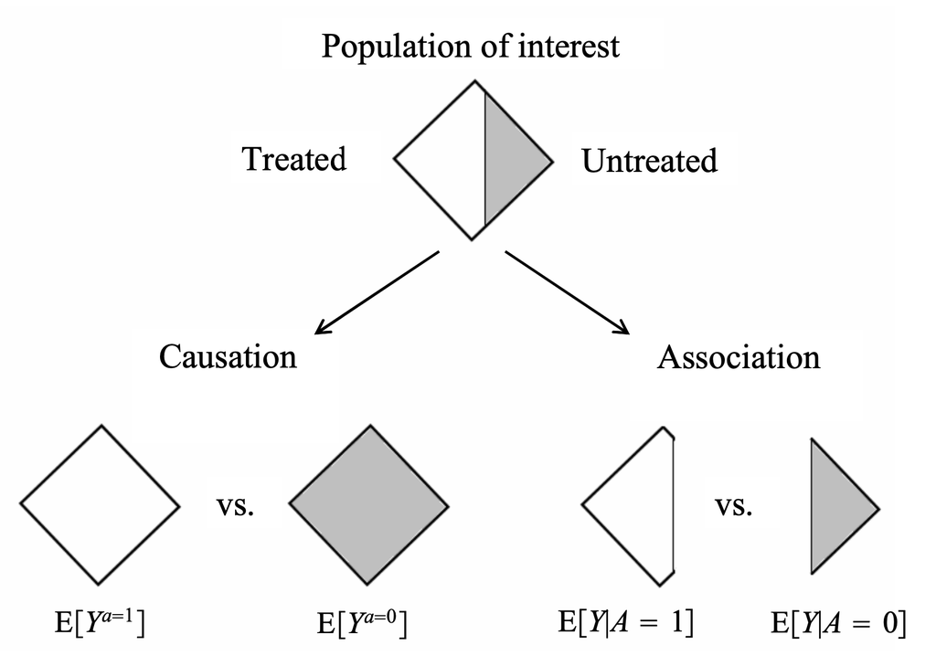

因果と関連の違い（Hernán and Robins (2020) のFigure 1.1）

$E[Y^{a=1}]$は「もし全員が$a=1$という処置を受けていたら」という状況における$Y$の期待値を，$E[Y^{a=0}]$は「もし全員が$a=0$という処置を受けていなかったら」という状況における$Y$の期待値を示し，因果効果はその2つの状況のコントラストから求めることができる．一方で，関連は処置によって集団に分け，異なる集団のアウトカムを比較している．

Morgan and Winship (2014) は差でとらえられる関連 $\tau_{\rm naïve} = [Y│A=1]-E[Y│A=0]$ を次のように分解する．

$$\begin{eqnarray}\tau_{\rm naïve}&=&E[Y│A=1]-E[Y│A=0]\\
&=&E[Y^1│A=1]-E[Y^0│A=0]
\\&=& \underbrace{E[\tau]}_\text{因果効果}+
\underbrace{\{[Y^0|A=1]-E[Y^0|A=0]\}}_\text{ベースラインの差}+
\underbrace{(1-\pi)\{E[\tau|A=1]-E[\tau|A=0]\}}_\text{因果効果の異質性}\end{eqnarray}$$

以上の関係が成り立つことを示そう． $E[\tau]=e$，$E[Y^1│A=1]=a$，$E[Y^1│A=0]=b$，$E[Y^0│A=1]=c$，$E[Y^0│A=0]=d$ とすると，

$$e=\pi (a-c)+(1-\pi)(b-d)=\{\pi a+(1-\pi)b\}-\{\pi c+(1-\pi)d\}$$

となる．

これは，

$$-d=e-\{\pi a+(1-\pi )b\}+\pi c-\pi d$$

なので，

$$\begin{eqnarray}a-d&=&a+e-\{\pi a+(1-\pi )b\}+\pi c-\pi d
\\&=&e+a-b-\pi a+\pi b+\pi c-\pi d
\\&=&e+(1-\pi )a-(1-\pi )b-(1-\pi )c+c+(1-\pi )d-d
\\&=&e+\{c-d\}+(1-\pi )\{(a-c)-(b-d)\}
\end{eqnarray}$$

とすることで簡単に示すことができる (Morgan and Winship 2014)．つまり平均の差でとらえた関連は，平均処置効果$E[\tau]$，ベースラインの偏り$\{[Y^0│A=1]-E[Y^0│A=0]\}$，そして異なる処置効果による偏り$(1-\pi )\{E[\tau│A=1]-E[\tau|A=0]\}$に分解することが可能である．つまり，観察データに基づく単純な差はベースラインと異なる処置効果による2つの偏りが存在し，平均処置効果とは一致しない．ベースラインの偏りは処置前から存在する状態の異質性であり，例えば学力や仕事に対する態度が考えられ，このような異質性は処置にもアウトカムにも影響する (Brand and Xie 2010)．また処置効果の異質性は，例えば大学進学した集団と大学進学しなかった集団では，大学進学が所得に与える因果効果が異なるというものである (Brand and Xie 2010)．もしベースラインの偏りや因果効果の異質性がなければ，関連は因果（$\tau_{\rm naïve}=E[\tau]$）ということができる．

大学進学が健康に与える影響を例に考えると，大学進学した集団と大学進学していない集団に見られる平均的な健康状態の差は，（1）大学進学そのものが健康状態を改善する（ATE），（2）大学進学した集団はそもそも平均的に健康状態が良い（ベースラインの偏り，処置前の異質性），（3）大学進学した集団の健康状態の改善は，大学進学しなかった集団が大学進学した場合の健康状態の改善よりも大きい（効果の異質性）という3つのプロセスによって生じているといえる．

Abadie and Cattaneo (2018) も同様の分解を行っている．

$$\begin{eqnarray}
\tau_{\rm naïve}&=&E[Y│A=1]-E[Y│A=0]\\
&=& \tau + (E[Y^1│A=1]-E[Y^1│A=0])P[A=0] + (E[Y^0│A=1]-E[Y^0│A=0])P[A=1]\\
&=& \tau + (E[Y^1│A=1]-E[Y^1│A=0])P[A=0] + (E[Y^0│A=1]-E[Y^0│A=0])(1 - P[A=0])\\
&=& \tau + (E[Y^1│A=1] - E[Y^0│A=1] - (E[Y^1│A=0] - E[Y^0│A=0]))P[A=0] + (E[Y^0│A=1]-E[Y^0│A=0])\\
&=& \tau + (ATT - ATC)P[A=0] + (E[Y^0│A=1]-E[Y^0│A=0])
\end{eqnarray}$$

# 3 ランダム化実験ではなぜ因果効果を求めることができるとされているのか

「ランダム化実験でなければ因果効果を明らかにすることができない」と言われることがある．

データから因果効果を求めることができるような時，因果効果が識別される（identified）と呼ばれる．あるいは関連から純粋な因果的な要素のみを取り出すことができることを，因果効果が識別されると言う．では，ランダム化実験ではなぜ因果効果が分かると言えるのか，なぜランダム化実験で因果効果が識別されるのかをポテンシャルアウトカムを用いて確認したい．

それはランダム化実験では$A=1$となるか$A=0$となるかはランダム割付（random assignment）によって決定されるため，**交換可能性（exchangeability）**という仮定が理論的に妥当であると主張することができるからである．

交換可能性は処置を受けた集団（$A=1$）と処置を受けなかった集団（$A=0$）で処置を受けた場合のアウトカム（$Y^1$）の分布が同じだろうという仮定である．つまり交換可能性によって平均値（期待値）について，次が成り立つ．

$$E[Y^1|A=1]=E[Y^1|A=0]$$

したがってこれらは全体の期待値とも一致する．

$$E[Y^1|A=1]=E[Y^1|A=0]=E[Y^1]$$

同様に，処置を受けなかった場合のアウトカム（$Y^0$）についても， 処置を受けた集団（$A=1$）と処置を受けなかった集団（$A=0$）で同じである．

$$E[Y^0|A=1]=E[Y^0|A=0]$$

$$E[Y^0|A=1]=E[Y^0|A=0]=E[Y^0]$$

以上はどのような処置を受けたか（$A=1$あるいは$A=0$）にかかわらず，ポテンシャルアウトカム$Y^a$の分布は同じになるということを意味するので，次のように書くことができる．$\perp \!\! \perp$は独立であることを示す記号である．

$$Y^a \perp \!\! \perp A \ \ {\rm for \ all \ } a.$$

なお$Y \perp \!\! \perp A$ではないことに注意が必要である． これは処置$A$によって$Y$が異ならない，つまり$A$と$Y$に関連がないことを意味する．

実験ではこの交換可能性の仮定が妥当であるといえる． では交換可能性が妥当であればなぜ因果効果を明らかにすることができるのかを確認したい．ポテンシャルアウトカムで示される因果効果$\tau$を，様々なルールと仮定を用いて，観察データで示したい．

$$\begin{eqnarray}
\tau &=& E[Y^1-Y^0]\\
&=& E[Y^1]-[Y^0] \ \ \ \ {\rm (\because linearity \ of \ expectation)}\\
&=& E[Y^1|A=1]-E[Y^0|A=0] \ \ \ \ {\rm (\because exchangeability)}\\
&=& E[Y|A=1] - E[Y|A=0]. \ \ \ \ {\rm (\because consistency)}
\end{eqnarray}$$

つまり，交換可能性と一致性が成り立っていれば，$\tau$は処置を受けた集団（$A=1$）の$Y$の期待値$E[Y|A=1]$と処置を受けなかった集団（$A=0$）の$Y$の期待値$E[Y|A=0]$との差（つまりnaïve estimator）から平均処置効果を求めることができる．

ポテンシャルアウトカムで定義されおりデータから直接得ることのできなかった$\tau$を，交換可能性と一致性の仮定によって観察される$Y$と$A$と結びつけ，計算によって求めることができるようになった．

## 3.1 交換可能性が成り立っている場合

では架空のデータを用いて，交換可能性が成り立っている場合に本当に因果効果が求められるのかを明らかにしたい．

```r
pacman::p_load(tidyverse,
               estimatr,
               marginaleffects,
               knitr)
```

```r
set.seed(123456)
n <- 100000
Y0 <- rnorm(n = n, mean = 50, sd = 10)
tau <- rnorm(n = n, mean = 5, sd = 2)
Y1 <- Y0 + tau + rnorm(n = n, mean = 0, sd = 1)
c(Y1_mean = mean(Y1),
  Y0_mean = mean(Y0),
  tau = mean(tau))
```

```
  Y1_mean   Y0_mean       tau
55.034699 50.032767  5.004309
```

次に実際に処置をうけたかどうかを示す変数$A$を作成する．$A$は確率0.3で0を，確率0.7で1をとるようにしている．したがって，$Y^a \perp \! \! \perp A$であり， $A$は$Y^1$，$Y^0$，$\tau$などとは無関連である．

観察データである$Y$は一致性により$Y = AY^1 + (1 - A)Y^0$という関係から作成される．

```r
A <- rbinom(n = n, size = 1, prob = 0.7)
Y <- A*Y1 + (1 - A)*Y0
```

5つの変数からデータセットを作成する．

```r
df <- tibble(Y1,Y0,tau,A,Y)
df
```

```
# A tibble: 100,000 × 5
      Y1    Y0   tau     A     Y
   <dbl> <dbl> <dbl> <int> <dbl>
 1  66.4  58.3  8.07     1  66.4
 2  52.4  47.2  5.12     1  52.4
 3  49.8  46.4  1.81     0  46.4
 4  53.8  50.9  3.07     0  50.9
 5  78.4  72.5  5.83     1  78.4
 6  59.8  58.3  2.29     1  59.8
 7  71.4  63.1  5.83     1  71.4
 8  79.5  75.0  3.73     1  79.5
 9  62.8  61.7  2.10     1  62.8
10  50.9  45.7  5.93     1  50.9
# ℹ 99,990 more rows
```

全体の平均値を求めてみる．もしポテンシャルアウトカムの値がわかるのであればこれから$\tau$の値を求めることができる．

まずすべての変数の平均値を確認しておく．

```r
df |>
  summarise(across(everything(), mean)) |>
  kable()
```

| Y1 | Y0 | tau | A | Y |
| --- | --- | --- | --- | --- |
| 55.0347 | 50.03277 | 5.004309 | 0.7012 | 53.53946 |

では処置$A$の値ごとに平均値を求めてみる．縦に比較すると$A$の値に関わらず$Y^1$の値がほぼ同じであることがわかる．また同様に$A$の値に関わらず$Y^0$の値がほぼ同じであることがわかる．

```r
df |>
  group_by(A) |>
  summarise(across(everything(), mean)) |>
  kable()
```

| A | Y1 | Y0 | tau | Y |
| --- | --- | --- | --- | --- |
| 0 | 55.01893 | 50.01480 | 5.011488 | 50.01480 |
| 1 | 55.04142 | 50.04042 | 5.001250 | 55.04142 |

よって処置別に$Y$の平均値をとり，それらの差（関連）を求めると因果効果となる．次の2つの値はほぼ同じとなる．つまり関連は因果効果と一致していることが分かる．

```r
# 因果効果
mean(df$Y1) - mean(df$Y0)
```

```
[1] 5.001932
```

```r
# 関連
mean(df$Y[df$A == 1]) - mean(df$Y[df$A == 0])
```

```
[1] 5.026622
```

以上のようにしてランダム化実験では個体処置効果は分からないが，平均処置効果は分かるのである．

## 3.2 交換可能性が成り立っていない場合

では交換可能性が成り立たない場合を考えてみよう．次の例は$Y^1$の値によって処置が割り当てられる確率が異なるとしている．$Y^1>50$の場合，$A=1$となる確率は0.4，$Y^1\leq 50$の場合，$A=1$となる確率は0.2としており，ポテンシャルアウトカムの値が高ければ，処置を受けやすいという関係がある．

```r
df2 <- tibble(Y1,Y0,Y,tau)
set.seed(123456)
df2 <- df2 |> mutate(A = case_when(
  Y1 > 50 ~ rbinom(n = length(Y1 > 50), size = 1, prob = 0.4),
  Y1 <= 50 ~ rbinom(n = length(Y1  <= 50), size = 1, prob = 0.2)),
  Y = A*Y1 + (1 - A)*Y0)
df2 <- df2 |> dplyr::select(Y1,Y0,tau,A,Y)
df2
```

```
# A tibble: 100,000 × 5
      Y1    Y0   tau     A     Y
   <dbl> <dbl> <dbl> <int> <dbl>
 1  66.4  58.3  8.07     1  66.4
 2  52.4  47.2  5.12     1  52.4
 3  49.8  46.4  1.81     1  49.8
 4  53.8  50.9  3.07     0  50.9
 5  78.4  72.5  5.83     0  72.5
 6  59.8  58.3  2.29     0  58.3
 7  71.4  63.1  5.83     0  63.1
 8  79.5  75.0  3.73     0  75.0
 9  62.8  61.7  2.10     1  62.8
10  50.9  45.7  5.93     0  45.7
# ℹ 99,990 more rows
```

```r
df2 |>
  summarise(across(everything(), mean)) |>
  kable()
```

| Y1 | Y0 | tau | A | Y |
| --- | --- | --- | --- | --- |
| 55.0347 | 50.03277 | 5.004309 | 0.33726 | 51.75459 |

```r
df2 |>
  group_by(A) |>
  summarise(across(everything(), mean)) |>
  kable()
```

| A | Y1 | Y0 | tau | Y |
| --- | --- | --- | --- | --- |
| 0 | 53.95703 | 49.00772 | 4.956930 | 49.00772 |
| 1 | 57.15240 | 52.04706 | 5.097411 | 57.15240 |

このとき，交換可能性が成り立っていないため，$E[Y^1|A=0]\neq E[Y^1|A=1]$であり，そして$E[Y^0|A=0]\neq E[Y^0|A=1]$である．

よって処置別に$Y$の平均値をとり，その差をもとめても因果効果とは一致しない．つまり関連は因果効果とはならない．

```r
# 因果効果
mean(df2$Y1) - mean(df2$Y0)
```

```
[1] 5.001932
```

```r
# 関連
mean(df2$Y[df2$A == 1]) - mean(df2$Y[df2$A == 0])
```

```
[1] 8.144681
```

## 3.3 条件付きで交換可能性が成り立っている場合

では条件付きで交換可能性が成り立っている場合を考える． ある変数$L$は$Y^1$と関連しており，また$L$の値によって$A$となる確率が異なる．$L=1$の場合は確率0.7で$A=1$となり，$L=0$の場合は確率0.4で$A=1$となる．

```r
df3 <- tibble(Y1,Y0,Y,tau)
set.seed(123456)
df3 <- df3 |> mutate(L = case_when(
  Y1 > 50 ~ rbinom(n = length(Y1 > 50), size = 1, prob = 0.5),
  Y1 <= 50 ~ rbinom(n = length(Y1  <= 50), size = 1, prob = 0.3)),
  A = case_when(
    L == 1 ~
      rbinom(n = length(L == 1), size = 1, prob = 0.7),
    L == 0 ~
      rbinom(n = length(L == 0), size = 1, prob = 0.4)),
  Y = A*Y1 + (1 - A)*Y0)
df3 <- df3 |> dplyr::select(Y1,Y0,tau,A,L,Y)
df3
```

```
# A tibble: 100,000 × 6
      Y1    Y0   tau     A     L     Y
   <dbl> <dbl> <dbl> <int> <int> <dbl>
 1  66.4  58.3  8.07     0     1  58.3
 2  52.4  47.2  5.12     1     1  52.4
 3  49.8  46.4  1.81     1     1  49.8
 4  53.8  50.9  3.07     0     0  50.9
 5  78.4  72.5  5.83     0     0  72.5
 6  59.8  58.3  2.29     1     0  59.8
 7  71.4  63.1  5.83     1     1  71.4
 8  79.5  75.0  3.73     1     0  79.5
 9  62.8  61.7  2.10     1     1  62.8
10  50.9  45.7  5.93     0     0  45.7
# ℹ 99,990 more rows
```

```r
df3 |>
  summarise(across(everything(), mean)) |>
  kable()
```

| Y1 | Y0 | tau | A | L | Y |
| --- | --- | --- | --- | --- | --- |
| 55.0347 | 50.03277 | 5.004309 | 0.53232 | 0.43685 | 52.70589 |

$L$によって$Y^1$や$Y^0$の値は異なる．

```r
df3 |>
  group_by(L) |>
  summarise(across(everything(), mean)) |>
  kable()
```

| L | Y1 | Y0 | tau | A | Y |
| --- | --- | --- | --- | --- | --- |
| 0 | 53.79603 | 48.85353 | 4.950560 | 0.4039776 | 50.85189 |
| 1 | 56.63149 | 51.55294 | 5.073597 | 0.6977681 | 55.09591 |

$A$によって$Y^1$や$Y^0$の値は異なる．

```r
df3 |>
  group_by(A) |>
  summarise(across(everything(), mean)) |>
  kable()
```

| A | Y1 | Y0 | tau | L | Y |
| --- | --- | --- | --- | --- | --- |
| 0 | 54.59446 | 49.61498 | 4.988182 | 0.2823084 | 49.61498 |
| 1 | 55.42147 | 50.39982 | 5.018477 | 0.5726255 | 55.42147 |

$L$の値別にみると，$A$によって$Y^1$や$Y^0$の値は大きくは異ならない．

```r
df3 |>
  group_by(L,A) |>
  summarise(across(everything(), mean)) |>
  kable()
```

| L | A | Y1 | Y0 | tau | Y |
| --- | --- | --- | --- | --- | --- |
| 0 | 0 | 53.80096 | 48.86132 | 4.956343 | 48.86132 |
| 0 | 1 | 53.78875 | 48.84202 | 4.942028 | 53.78875 |
| 1 | 0 | 56.61173 | 51.53095 | 5.069125 | 51.53095 |
| 1 | 1 | 56.64005 | 51.56247 | 5.075534 | 56.64005 |

つまり，

$$E[Y^1|A=1,L=1] = E[Y^1|A=0,L=1].$$
$$E[Y^0|A=1,L=1] = E[Y^0|A=0,L=1].$$

である．同様に，

$$E[Y^1|A=1,L=0] = E[Y^1|A=0,L=0].$$
$$E[Y^0|A=1,L=0] = E[Y^0|A=0,L=0].$$

となる．これを条件つき交換可能性（conditional exchangeability）とよび，

$$Y^a \perp \!\! \perp A|L {\rm \ \ for \ all \ } a.$$

と表記する．

このようにすれば$L$の値ごとに因果効果を求めることができる．条件つき交換可能性が成り立っているとき，$L=l$の場合の平均処置効果を求めてみたい．

$$\begin{eqnarray}
E[Y^1-Y^0|L=l] &=& E[Y^1|L=l]-E[Y^0|L=l] \ \ \ \ {\rm (\because linearity \ of \ expectation)}\\
&=& E[Y^1|A=1,L=l]-E[Y^0|A=0,L=l] \ \ \ \ {\rm (\because conditional \ exchangeability)} \\
&=& E[Y|A=1,L=l]-E[Y|A=0,L=l]. \ \ \ \ {\rm (\because consistency)}\\
\end{eqnarray}$$

このようにすると$E[Y^1-Y^0|L=0]$や$E[Y^1-Y^0|L=1]$といった複数の平均処置効果が求められる．

## 3.4 標準化（standardization）

しかしわれわれの関心は対象となっている集団全体についての平均処置効果知りたい場合が多い．そこでこの$L$別の平均処置効果の重み付け平均を用いる．重み付けに用いるのは$L=l$となる確率$\Pr[L=l]$である．$L=0$と$L=1$の場合の$E[Y^1]$と$E[Y^0]$を考えてみる．

$$\begin{eqnarray}
E[Y^1] &=& E[Y^1|L=1]\Pr[L=1] + E[Y^1|L=0]\Pr[L=0] \\
&=& E[Y^1|A=1,L=1]\Pr[L=1] + E[Y^1|A=1,L=0]\Pr[L=0] \\
&=& E[Y|A=1,L=1]\Pr[L=1] + E[Y|A=1,L=0]\Pr[L=0]. \\
\end{eqnarray}$$

同様に，

$$\begin{eqnarray}
E[Y^0] &=& E[Y^0|L=1]\Pr[L=1] + E[Y^0|L=0]\Pr[L=0] \\
&=& E[Y^0|A=0,L=1]\Pr[L=1] + E[Y^0|A=0,L=0]\Pr[L=0] \\
&=& E[Y|A=0,L=1]\Pr[L=1] + E[Y|A=0,L=0]\Pr[L=0]. \\
\end{eqnarray}$$

一般的には次のように表すことができる．このような方法を標準化（standardization）と呼び，標準化によって得られた平均値を標準化平均（standardized mean）と呼ぶ (Hernán and Robins 2020, 19; Morgan and Winship 2014, 147; Pearl, Glymour, and Jewell 2016, 57)．

$$E[Y^a] = \sum_l E[Y|A=a,L=l]\Pr[L=l].$$

なお，$Pr[A=a|L=l]>0$という正値性（positivity） が成り立っている必要がある (Hernán and Robins 2020, 32; Morgan and Winship 2014, 148)

2つの標準化平均を用いて，平均処置効果は次のようにして求められる．

$$\begin{eqnarray}
\tau &=& E[Y^1] - E[Y^0]\\
&=& \sum_l E[Y|A=1,L=l]\Pr[L=l] - \sum_l E[Y|A=0,L=l]\Pr[L=l] \\
&=& \sum_l \left\{E[Y|A=1,L=l] - E[Y|A=0,L=l]\right\}\Pr[L=l].
\end{eqnarray}$$

では先ほどの例から因果効果を求めてみよう．まずは全体の平均と$L$と$A$の層別の平均値を求める．

```r
df3 |>
  summarise(across(everything(), mean)) |>
  knitr::kable()
```

| Y1 | Y0 | tau | A | L | Y |
| --- | --- | --- | --- | --- | --- |
| 55.0347 | 50.03277 | 5.004309 | 0.53232 | 0.43685 | 52.70589 |

```r
df3 |>
  group_by(L,A) |>
  summarise(across(everything(),mean)) |>
  knitr::kable()
```

| L | A | Y1 | Y0 | tau | Y |
| --- | --- | --- | --- | --- | --- |
| 0 | 0 | 53.80096 | 48.86132 | 4.956343 | 48.86132 |
| 0 | 1 | 53.78875 | 48.84202 | 4.942028 | 53.78875 |
| 1 | 0 | 56.61173 | 51.53095 | 5.069125 | 51.53095 |
| 1 | 1 | 56.64005 | 51.56247 | 5.075534 | 56.64005 |

$\Pr[L=1]=0.43685$，$\Pr[L=0]=1-0.43685=0.56315$である．よって

$$\begin{eqnarray}
E[Y^1] &=& E[Y|A=1,L=0]\Pr[L=0] + E[Y|A=1,L=1]\Pr[L=1] \\
&=& 53.78875 * (1-0.43685) + 56.64005 * 0.43685 \\
&=& 55.03434.
\end{eqnarray}$$

$$\begin{eqnarray}
E[Y^0] &=& E[Y|A=0,L=0]\Pr[L=0] + E[Y|A=0,L=1]\Pr[L=1] \\
&=& 48.86132 * (1-0.43685) + 51.53095 * 0.43685 \\
&=& 50.02755.
\end{eqnarray}$$

したがって，

$$E[Y^1] - E[Y^0] = 55.03434 - 50.02755 = 5.00679.$$

となる．

$L$が複数の変数から成り立っていたりまた連続変数だったりする場合もあるが，回帰モデルなどで$E[Y|A=a,L=l]$を推定し，その個人レベルでの予測値$\hat E[Y|A=a,L_i]$を用いて集団全体での平均値を求めればよい．

$$\frac{1}{n}\sum_{i=1}^n\hat E[Y_i|A_i=a,L_i]$$

例えば次のようなデータがあるとする．条件付き交換可能性が成り立っているものとする．

```r
df4 <- df3 |> dplyr::select(Y,A,L)
df4
```

```
# A tibble: 100,000 × 3
       Y     A     L
   <dbl> <int> <int>
 1  58.3     0     1
 2  52.4     1     1
 3  49.8     1     1
 4  50.9     0     0
 5  72.5     0     0
 6  59.8     1     0
 7  71.4     1     1
 8  79.5     1     0
 9  62.8     1     1
10  45.7     0     0
# ℹ 99,990 more rows
```

加えてすべての処置が$A=0$であるデータ（`a = 0`）と$A=1$であるデータ（`a = 1`）を作成し，`bind_rows`によって積み重ねる．

```r
df4_untreated <- df4 |> mutate(Y = NA,
                                A = 0,   # A = 0に変換
                                a = 0)
df4_treated <- df4 |> mutate(Y = NA,
                              A = 1,   # A = 1に変換
                              a = 1)
df4_stacked <- bind_rows(df4, df4_untreated, df4_treated)
```

$E[Y|A=a,L=l]$を回帰モデル$Y=\beta_0 + \beta_1A + \beta_2L + \beta_3AL$で推定し，係数を求める．

```r
fit <- df4_stacked |>
  lm(Y ~ A * L, data = _)
```

求めた係数を用いて，`df4_untreated`と`df4_treated`の$Y$をそれぞれ求める．

```r
predicted_mean <- broom::augment(fit, newdata = df4_stacked)
predicted_mean |> filter(is.na(a))
```

```
# A tibble: 100,000 × 6
       Y     A     L     a .fitted .resid
   <dbl> <dbl> <int> <dbl>   <dbl>  <dbl>
 1  58.3     0     1    NA    51.5   6.81
 2  52.4     1     1    NA    56.6  -4.28
 3  49.8     1     1    NA    56.6  -6.84
 4  50.9     0     0    NA    48.9   2.01
 5  72.5     0     0    NA    48.9  23.7
 6  59.8     1     0    NA    53.8   6.00
 7  71.4     1     1    NA    56.6  14.8
 8  79.5     1     0    NA    53.8  25.7
 9  62.8     1     1    NA    56.6   6.21
10  45.7     0     0    NA    48.9  -3.12
# ℹ 99,990 more rows
```

```r
predicted_mean |> filter(a == 0)
```

```
# A tibble: 100,000 × 6
       Y     A     L     a .fitted .resid
   <dbl> <dbl> <int> <dbl>   <dbl>  <dbl>
 1    NA     0     1     0    51.5     NA
 2    NA     0     1     0    51.5     NA
 3    NA     0     1     0    51.5     NA
 4    NA     0     0     0    48.9     NA
 5    NA     0     0     0    48.9     NA
 6    NA     0     0     0    48.9     NA
 7    NA     0     1     0    51.5     NA
 8    NA     0     0     0    48.9     NA
 9    NA     0     1     0    51.5     NA
10    NA     0     0     0    48.9     NA
# ℹ 99,990 more rows
```

```r
predicted_mean |> filter(a == 1)
```

```
# A tibble: 100,000 × 6
       Y     A     L     a .fitted .resid
   <dbl> <dbl> <int> <dbl>   <dbl>  <dbl>
 1    NA     1     1     1    56.6     NA
 2    NA     1     1     1    56.6     NA
 3    NA     1     1     1    56.6     NA
 4    NA     1     0     1    53.8     NA
 5    NA     1     0     1    53.8     NA
 6    NA     1     0     1    53.8     NA
 7    NA     1     1     1    56.6     NA
 8    NA     1     0     1    53.8     NA
 9    NA     1     1     1    56.6     NA
10    NA     1     0     1    53.8     NA
# ℹ 99,990 more rows
```

データセット別に予測値の平均値を求める．

```r
predicted_mean |>
  group_by(a) |>
  summarise(mean_Y = mean(.fitted)) |>
  knitr::kable()
```

| a | mean_Y |
| --- | --- |
| 0 | 50.02755 |
| 1 | 55.03434 |
| NA | 52.70589 |

よって先ほどと同様の値が得られた．

$$E[Y^1] - E[Y^0] = 55.03434 - 50.02755 = 5.00679.$$

しかしこのような方法はやや煩雑であるし，標準誤差や信頼区間を求めたい場合はブートストラップ法などを使用する必要がある． そこで同様の計算を限界効果を用いて行う．

`marginaleffects`パッケージの`comparison`関数を用いて，平均処置効果を求めたい．フィットしたモデルに対して`comparison`を用い，`variables`で比較したい変数とその値を指定する．今回は`A`という変数が`0`の場合と`1`の場合を比較する．

```r
df3 |> dplyr::select(Y,A,L) |>
  lm(Y ~ A * L, data = _) |>
  comparisons(variables = list(A = 0:1)) |>
  head()
```

```
 Term Contrast Estimate Std. Error    z Pr(>|z|)   S 2.5 % 97.5 %
    A    1 - 0     5.11     0.1045 48.9   <0.001 Inf  4.90   5.31
    A    1 - 0     5.11     0.1045 48.9   <0.001 Inf  4.90   5.31
    A    1 - 0     5.11     0.1045 48.9   <0.001 Inf  4.90   5.31
    A    1 - 0     4.93     0.0862 57.2   <0.001 Inf  4.76   5.10
    A    1 - 0     4.93     0.0862 57.2   <0.001 Inf  4.76   5.10
    A    1 - 0     4.93     0.0862 57.2   <0.001 Inf  4.76   5.10

Columns: rowid, term, contrast, estimate, std.error, statistic, p.value, s.value, conf.low, conf.high, predicted_lo, predicted_hi, predicted, Y, A, L
```

すると個人が$A=1$の場合と$A=0$の場合の比較の結果が`comparison`に示されるので， これらの平均値を`summary`で求める．

```r
df3 |> dplyr::select(Y,A,L) |>
  lm(Y ~ A * L, data = _) |>
  comparisons(variables = list(A = 0:1)) |>
  summary() |>
  kable()
```

| term | contrast | estimate | std.error | statistic | p.value | conf.low | conf.high |
| --- | --- | --- | --- | --- | --- | --- | --- |
| A | mean(1) - mean(0) | 5.006791 | 0.066632 | 75.1409 | 0 | 4.876194 | 5.137387 |

この`Effect`あるいは`estimate`の値が平均処置効果である．しかもこの方法のよい点は標準誤差が容易に求められるという点である．

このような予測（回帰モデルと機械学習）と因果推論の関連については Lundberg, Johnson, and Stewart (2021) や Lundberg, Brand, and Jeon (2022) を読むとよい．

## 3.5 IPTW

逆確率重み付け（IPTW: inverse probability of treatment weighting）という方法でも同様に因果効果を求めることができる． ただし$L$は$A$の親である．これは先ほどと全く別の方法を用いているというわけではなく，数学的には同じになる．

まず$\Pr[A=1|L]$の確率を求める．これは傾向スコア（propensity score）ともよばれ，$e(L_i)$と 表記される．$\Pr[A_i=0|L_i]$の確率は1から傾向スコアを引けばよい．ここでは単に$PS$と表記する．

$$PS_i = e(L_i) = \Pr[A_i=1|L_i]$$

これを用いて次のようなウェイトを求める．

$$w_i = \frac{A_i}{PS_i} + \frac{1-A_i}{1-PS_i}$$

これは処置が$A=1$の場合には$PS$の逆数を，$A=0$の場合には$1-PS$の逆数をウェイトとしている．このウェイトを用いることによって，$A$と$L$が独立した疑似集団（pseudo-population）のデータを作成することができる）．ただし，傾向スコアがあまりにも小さかったり大きかったりすることで，ウェイトが大きくなってしまうので，注意が必要である．また，$A$と$L$が本当に独立しているのかどうかはチェックする必要がある．

```r
df3 <- df3 |>
  group_by(L) |>
  mutate(PS = mean(A),
         w_1 = case_when(A == 1 ~ 1/PS,
                         TRUE ~ 0),
         w_0 = case_when(A == 0 ~ 1/(1-PS),
                         TRUE ~ 0)
         ) |>
  ungroup()
```

```r
df3 <- df3 |>
  mutate(sum_w_0 = sum(w_0),
         sum_w_1 = sum(w_1))
```

ウェイト付きの平均値は次のようにして求められる．

$$\frac{\sum_i^n w_i Y_i}{\sum_i^n w_i}.$$

```r
df3 |>
  filter(A == 0) |>  # あってもなくてもよい
  summarise(sum(w_0*Y),
            sum(w_0),
            Y0 = sum(w_0*Y)/sum(w_0)) |>
  kable(format = "simple")
```

| sum(w_0 * Y) | sum(w_0) | Y0 |
| --- | --- | --- |
| 5002755 | 1e+05 | 50.02755 |

```r
df3 |>
  filter(A == 1) |>  # あってもなくてもよい
  summarise(sum(w_1*Y),
            sum(w_1),
            Y1 = sum(w_1*Y)/sum(w_1)) |>
  kable(format = "simple")
```

| sum(w_1 * Y) | sum(w_1) | Y1 |
| --- | --- | --- |
| 5503434 | 1e+05 | 55.03434 |

結局$A$の値別にウェイトを用いて集計するので，ひとつのウェイトにまとめてしまおう．

```r
df3 <- df3 |>
  group_by(L) |>
  mutate(PS = mean(A),
         w = A/PS + (1 - A)/(1 - PS)) |>
  ungroup()
df3
```

```
# A tibble: 100,000 × 12
      Y1    Y0   tau     A     L     Y    PS   w_1   w_0 sum_w_0 sum_w_1     w
   <dbl> <dbl> <dbl> <int> <int> <dbl> <dbl> <dbl> <dbl>   <dbl>   <dbl> <dbl>
 1  66.4  58.3  8.07     0     1  58.3 0.698  0     3.31 100000. 100000.  3.31
 2  52.4  47.2  5.12     1     1  52.4 0.698  1.43  0    100000. 100000.  1.43
 3  49.8  46.4  1.81     1     1  49.8 0.698  1.43  0    100000. 100000.  1.43
 4  53.8  50.9  3.07     0     0  50.9 0.404  0     1.68 100000. 100000.  1.68
 5  78.4  72.5  5.83     0     0  72.5 0.404  0     1.68 100000. 100000.  1.68
 6  59.8  58.3  2.29     1     0  59.8 0.404  2.48  0    100000. 100000.  2.48
 7  71.4  63.1  5.83     1     1  71.4 0.698  1.43  0    100000. 100000.  1.43
 8  79.5  75.0  3.73     1     0  79.5 0.404  2.48  0    100000. 100000.  2.48
 9  62.8  61.7  2.10     1     1  62.8 0.698  1.43  0    100000. 100000.  1.43
10  50.9  45.7  5.93     0     0  45.7 0.404  0     1.68 100000. 100000.  1.68
# ℹ 99,990 more rows
```

なお，$Y^a$の平均はウェイトがあってもなくても同じである．

```r
df3 |>
  summarise(Y1_mean = mean(Y1),
            Y1_weighted_mean = sum(w*Y1)/sum(w),
            Y0_mean = mean(Y0),
            Y0_weighted_mean = sum(w*Y0)/sum(w)) |>
  kable(format = "simple")
```

| Y1_mean | Y1_weighted_mean | Y0_mean | Y0_weighted_mean |
| --- | --- | --- | --- |
| 55.0347 | 55.03159 | 50.03277 | 50.029 |

このウェイトを用いると$L$と$A$は独立である．これは処置を受けた集団と受けなかった集団で後述する$L$のバランスがとられていることを示している．

```r
df3 |>
  group_by(A) |>
  summarise(mean_L = mean(L),
            sum(L*w),
            sum(w),
            weighted_L = sum(L*w)/sum(w))  |>
  kable(format = "simple")
```

[output not shown]

次のような方法でも確認できる．

```r
# ウェイトを用いない場合は係数が0と頃なる．
df3 |>
  lm_robust(L ~ A, data = _) |>
  tidy()
```

```
         term  estimate   std.error statistic p.value  conf.low conf.high    df
1 (Intercept) 0.2823084 0.002081427  135.6322       0 0.2782288  0.286388 99998
2           A 0.2903171 0.002988271   97.1522       0 0.2844601  0.296174 99998
  outcome
1       L
2       L
```

```r
# ウェイトを用いた場合は係数が0と頃なる．
df3 |>
  lm_robust(L ~ A, weights = w, data = _) |>
  tidy()
```

```
         term     estimate   std.error    statistic p.value     conf.low
1 (Intercept) 4.368500e-01 0.002527303 1.728522e+02       0  0.431896516
2           A 1.808079e-15 0.003321620 5.443366e-13       1 -0.006510334
    conf.high    df outcome
1 0.441803484 99998       L
2 0.006510334 99998       L
```

この処置別にウェイトを用いた和（加重平均）を求めると， $A=1$のときの$Y$の加重平均は$E[Y^1]$となり， $A=0$のときの$Y$の加重平均は$E[Y^0]$となる．

```r
df3 |>
  group_by(A) |>
  summarise(sum(Y*w),
            sum(w),
            weighted_Y = sum(Y*w)/sum(w)) |>
  knitr::kable(format = "simple")
```

[output not shown]

`weighted.mean`関数を用いても確認できる．ウェイト（`w`）をかけると，$L$によって$A$が異ならない．

```r
df3 |>
  group_by(L) |>
  summarise(prob_A = mean(A),
            weighted_prob_A = weighted.mean(A, w = w)) |>
  knitr::kable(format = "simple")
```

[output not shown]

```r
df3 |>
  group_by(A) |>
  summarise(prob_L = mean(L),
            weighted_prob_L = weighted.mean(L, w = w)) |>
  knitr::kable(format = "simple")
```

[output not shown]

このようなウェイト`IPTW`を用いて，$Y$の重み付け平均値を求める．

```r
df3 |>
  group_by(A) |>
  summarise(mean_Y = mean(Y),
            weighted_mean_Y = weighted.mean(Y, w = w)) |>
  knitr::kable(format = "simple")
```

[output not shown]

したがって，

$$E[Y^1] - E[Y^0] = 55.03434 - 50.02755 = 5.00679.$$

次のようにしてもよい．

```r
df3 |>
  mutate(treated = (A==1) / PS * Y ,
         untreated = (A==0) / (1-PS) * Y) |>
  summarise(mean_treated = mean(treated),
            mean_untreated = mean(untreated)) |>
  mutate(tau = mean_treated - mean_untreated) |>
  knitr::kable(format = "simple")
```

| mean_treated | mean_untreated | tau |
| --- | --- | --- |
| 55.03434 | 50.02755 | 5.006791 |

回帰分析で`weights`にIPTWを用いることで，$E[Y^1]-E[Y^0]$の値を$A$の係数より求めることもできる．つまり$E_{ps}[Y|A=1]-E_{ps}[Y|A=0]$を，ウェイトのあるデータでの回帰モデルつまり疑似集団での回帰モデル$E[Y|A] = \beta_0 + \beta_1 A$の$\beta_1$によって推定する．

単純な平均の差$E[Y|A=1]-E[Y|A=0]$はウェイトのない単回帰分析$E[Y|A] = \beta_0 + \beta_1 A$における$A$の係数$\beta_1$である．

```r
df3 |>
  lm_robust(Y ~ A, data = _)
```

```
             Estimate Std. Error    t value Pr(>|t|)  CI Lower  CI Upper    DF
(Intercept) 49.614981 0.04676227 1061.00456        0 49.523327 49.706634 99998
A            5.806494 0.06412939   90.54342        0  5.680801  5.932187 99998
```

`weights`に`IPTW`を用いて因果効果（$E_{ps}[Y|A=1]-E_{ps}[Y|A=0]$）を求める．

```r
df3 |>
  lm_robust(Y ~ A, weights = w, data = _)
```

```
             Estimate Std. Error    t value Pr(>|t|)  CI Lower  CI Upper    DF
(Intercept) 50.027549 0.04831020 1035.54827        0 49.932861 50.122236 99998
A            5.006791 0.06695958   74.77333        0  4.875551  5.138031 99998
```

なお，ポテンシャルアウトカム$Y^a$の周辺期待値$E[Y^a]$を次のようにモデル化すると次のようになる．

$$E[Y^a]=\theta_0 + \theta_1a$$

通常のモデルと異なるのは，ポテンシャルアウトカム$Y^a$が対象となっており，また$A$によって条件付けられていない．あくまで周辺期待値$E[Y^a]$についてのモデルとなっている．これは周辺構造平均モデルと呼ばれる（marginal structural mean model）．

$a=0$のとき$E[Y^0]=\theta_0$であり，$a=1$のとき$E[Y^1]=\theta_0 + \theta_1$である．よって，

$$E[Y^1]-E[Y^0]=\theta_0 + \theta_1 - \theta_0 = \theta_1$$

となりこのモデルにおける$\theta_1$が推定対象となっている平均因果効果である． 先ほどの疑似集団での回帰モデルの$\beta_1$はこの$\theta$を求めるためのモデルである．

## もう少し簡単な例から考える

Snowden, Rose, and Mortimer (2011) のシミュレーションデータを用いて分析してみる．

```r
# データの作成
set.seed(285)
n <- 300
simdata <- tibble(W1 = rbinom(n = n, size = 1, prob = .4),
                  W2 = rbinom(n = n, size = 1, prob = .5)) |>
  mutate(A = rbinom(n = n, size = 1, prob = 0.5 + 0.2*W1 - 0.3*W2),
         Y = rnorm(n = n, mean = 3 - 0.5 * A + 1 * W1 + 0.3 * A * W2, sd = .4))
simdata |>
  summarise(across(everything(), mean))
```

```
# A tibble: 1 × 4
     W1    W2     A     Y
  <dbl> <dbl> <dbl> <dbl>
1 0.407 0.493 0.397  3.22
```

```r
simdata |> pull(Y) |> quantile()
```

```
      0%      25%      50%      75%     100%
1.356608 2.749801 3.120169 3.741440 4.850567
```

```r
# 回帰分析と標準化
simdata |> lm(Y ~ A, data = _)
```

```
Call:
lm(formula = Y ~ A, data = simdata)

Coefficients:
(Intercept)            A
     3.3077      -0.2253
```

```r
simdata |> lm(Y ~ A, data = _) |> comparisons(variables = "A") |> summary()
```

```
 Term          Contrast Estimate Std. Error     z Pr(>|z|)  2.5 % 97.5 %
    A mean(1) - mean(0)   -0.225     0.0792 -2.84  0.00447 -0.381  -0.07

Columns: term, contrast, estimate, std.error, statistic, p.value, conf.low, conf.high
```

```r
simdata |> lm(Y ~ A + W1 + W2, data = _)
```

```
Call:
lm(formula = Y ~ A + W1 + W2, data = simdata)

Coefficients:
(Intercept)            A           W1           W2
     2.8654      -0.3564       1.0606       0.1277
```

```r
simdata |> lm(Y ~ A + W1 + W2, data = _) |> comparisons(variables = "A") |> summary()
```

```
 Term          Contrast Estimate Std. Error     z Pr(>|z|) 2.5 % 97.5 %
    A mean(1) - mean(0)   -0.356      0.053 -6.73   <0.001 -0.46 -0.253

Columns: term, contrast, estimate, std.error, statistic, p.value, conf.low, conf.high
```

```r
simdata |> lm(Y ~ A + W1 + A * W2, data = _)
```

```
Call:
lm(formula = Y ~ A + W1 + A * W2, data = simdata)

Coefficients:
(Intercept)            A           W1           W2         A:W2
    2.93411     -0.47512      1.05055      0.02217      0.28758
```

```r
simdata |> lm(Y ~ A + W1 + A * W2, data = _) |> comparisons(variables = "A") |> summary()
```

```
 Term          Contrast Estimate Std. Error     z Pr(>|z|)  2.5 % 97.5 %
    A mean(1) - mean(0)   -0.333     0.0531 -6.28   <0.001 -0.437 -0.229

Columns: term, contrast, estimate, std.error, statistic, p.value, conf.low, conf.high
```

```r
simdata |> lm(Y ~ A + W1 + A : W2, data = _)
```

```
Call:
lm(formula = Y ~ A + W1 + A:W2, data = simdata)

Coefficients:
(Intercept)            A           W1         A:W2
     2.9476      -0.4889       1.0511       0.3096
```

```r
simdata |> lm(Y ~ A + W1 + A : W2, data = _) |> comparisons(variables = "A") |> summary()
```

```
 Term          Contrast Estimate Std. Error     z Pr(>|z|)  2.5 % 97.5 %
    A mean(1) - mean(0)   -0.336     0.0524 -6.42   <0.001 -0.439 -0.234

Columns: term, contrast, estimate, std.error, statistic, p.value, conf.low, conf.high
```

```r
simdata |> lm(Y ~ A + W1 + A * W2, data = _) |>
  broom::augment(newdata = simdata) |>
  count(W1, W2, A, .fitted)
```

```
# A tibble: 8 × 5
     W1    W2     A .fitted     n
  <int> <int> <int>   <dbl> <int>
1     0     0     0    2.93    47
2     0     0     1    2.46    46
3     0     1     0    2.96    72
4     0     1     1    2.77    13
5     1     0     0    3.98    22
6     1     0     1    3.51    37
7     1     1     0    4.01    40
8     1     1     1    3.82    23
```

```r
Y1_pred <- simdata |> lm(Y ~ A + W1 + A * W2, data = _) |>
  broom::augment(newdata = simdata |> mutate(A = 1)) |>
  count(W1, W2, A, .fitted) |>
  rename(Y1_pred = .fitted) |>
  dplyr::select(-A)
Y0_pred <- simdata |> lm(Y ~ A + W1 + A * W2, data = _) |>
  broom::augment(newdata = simdata |> mutate(A = 0)) |>
  count(W1, W2, A, .fitted) |>
  rename(Y0_pred = .fitted) |>
  dplyr::select(-A)
tau <- Y1_pred |> left_join(Y0_pred) |>
  mutate(tau = Y1_pred - Y0_pred,
         prob = n / sum(n)) |>
  dplyr::select(W1, W2, n, Y1_pred, Y0_pred, tau, prob)
tau
```

```
# A tibble: 4 × 7
     W1    W2     n Y1_pred Y0_pred    tau  prob
  <int> <int> <int>   <dbl>   <dbl>  <dbl> <dbl>
1     0     0    93    2.46    2.93 -0.475 0.31
2     0     1    85    2.77    2.96 -0.188 0.283
3     1     0    59    3.51    3.98 -0.475 0.197
4     1     1    63    3.82    4.01 -0.188 0.21
```

```r
tau |>
  summarise(tau = weighted.mean(tau, w = prob))
```

```
# A tibble: 1 × 1
     tau
   <dbl>
1 -0.333
```

IPTWによる分析をおこなう．

```r
# IPTW
## 傾向スコア
simdata |>
  group_by(W1, W2) |>
  summarise(ps = mean(A))
```

```
# A tibble: 4 × 3
# Groups:   W1 [2]
     W1    W2    ps
  <int> <int> <dbl>
1     0     0 0.495
2     0     1 0.153
3     1     0 0.627
4     1     1 0.365
```

```r
## 傾向スコア
t_model <- simdata |> glm(A ~ W1 * W2, family = binomial(link = "logit"), data = _)
tidy(t_model)
```

```
# A tibble: 4 × 5
  term        estimate std.error statistic    p.value
  <chr>          <dbl>     <dbl>     <dbl>      <dbl>
1 (Intercept)  -0.0215     0.207    -0.104 0.917
2 W1            0.541      0.340     1.59  0.111
3 W2           -1.69       0.366    -4.62  0.00000383
4 W1:W2         0.617      0.524     1.18  0.239
```

```r
simdata <- simdata |> mutate(ps = predict(t_model, type = "response"),
                   w_1 = A/ps,
                   w_0 = (1 - A) / (1 - ps),
                   w = A/ps + (1 - A) / (1 - ps))
```

`w_1`というウェイトは$W_1$と$W_2$が同じである$A=0$を$A=1$に置き換えている（`w_1Xn`をみよ）． 同様に`w_2`というウェイトは$W_1$と$W_2$が同じである$A=1$を$A=0$に置き換えている（`w_0Xn`をみよ）． よってこれらを合わせたウェイト`w`は共変量$W_1$と$W_2$が同じであるが$A$の値が異なる集団について， 全員が$A=0$だった場合と全員が$A=1$だった場合の集団の両方を作り出す． 条件付き交換可能性より，共変量$W_1$と$W_2$が同じ集団では$Y^1$の値は$A=1$の集団の$Y$の値によって，$Y^0$の値は$A=0$の集団の$Y$の値によって置き換えることができる．1つ目のウェイトは$Y^1$を求めるため，2つ目のウェイトは$Y^0$を求めるためのウェイトと考えることができる．

共変量$W_1$と$W_2$が同じである集団について$A=1$の人数も$A=0$の人数もほぼ同じとなるため， $A$と$W_1$や$W_2$の関連はなくなる．

```r
## ウェイト
simdata |>
  count(W1, W2, A, ps, w_1, w_0, w) |>
  mutate(w_1Xn = w_1 * n,
         w_0Xn = w_0 * n,
         wXn = w * n)
```

```
# A tibble: 8 × 11
     W1    W2     A    ps   w_1   w_0     w     n w_1Xn w_0Xn   wXn
  <int> <int> <int> <dbl> <dbl> <dbl> <dbl> <int> <dbl> <dbl> <dbl>
1     0     0     0 0.495  0     1.98  1.98    47   0    93    93
2     0     0     1 0.495  2.02  0     2.02    46  93     0    93
3     0     1     0 0.153  0     1.18  1.18    72   0    85    85
4     0     1     1 0.153  6.54  0     6.54    13  85.0   0    85.0
5     1     0     0 0.627  0     2.68  2.68    22   0    59.0  59.0
6     1     0     1 0.627  1.59  0     1.59    37  59.0   0    59.0
7     1     1     0 0.365  0     1.58  1.58    40   0    63.0  63.0
8     1     1     1 0.365  2.74  0     2.74    23  63.0   0    63.0
```

```r
simdata |> lm_robust(Y ~ A, weights = w, data = _)
```

```
              Estimate Std. Error   t value      Pr(>|t|)   CI Lower   CI Upper
(Intercept)  3.3717658 0.04891105 68.936682 3.483226e-185  3.2755109  3.4680206
A           -0.3400472 0.09181837 -3.703477  2.533655e-04 -0.5207417 -0.1593526
             DF
(Intercept) 298
A           298
```

## 3.6 標準化とIPTW

簡単に考えるために$Y$が$0$と$1$の2値変数とする．処置が$A=a$のときのポテンシャルアウトカムが1となる確率は次のようにして求めることができる．

$$\Pr[Y^a=1]=\sum_l \Pr[Y=1|A=a,L=l]\Pr[L=l]$$

また，処置が$A=a$のときのポテンシャルアウトカムが1となる確率はIPTWを用いると次のようにして求めることができる．これは母集団のそれぞれのケース$[Y=1,A=a,L=l]$の確率を$1/\Pr[A=a|L=l]$倍し，合計すればよいことになる．

$$\begin{eqnarray}
\Pr[Y^a=1] &=& \sum_l \frac{\Pr[Y=1,A=a,L=l]}{\Pr[A=a|L=l]}
\end{eqnarray}$$

次に示すように，標準化とIPTWは数学的には同じものとなり，モデルを用いて推定しない場合は同じ値となる．

$$\begin{eqnarray}
\Pr[Y^a=1] &=& \sum_l \Pr[Y=1|A=a,L=l]\Pr[L=l] \\
&=& \sum_l \frac{\Pr[Y=1|A=a,L=l]\Pr[A=a|L=l]\Pr[L=l]}{\Pr[A=a|L=l]}\\
&=& \sum_l \frac{\Pr[Y=1,A=a,L=l]}{\Pr[A=a|L=l]}.
\end{eqnarray}$$

モデルを用いる時に重要となるのは，標準化は$\Pr[Y=1|A=a,L=l]$という条件付き確率のモデル化が重要であるのに対して，IPTWでは$\Pr[A=a|L=l]$という条件付き確率のモデル化が重要となる． 前者はアウトカムについてのモデルであり，後者は処置についてのモデルである．

## 3.7 正値性（Positivity）

なお条件付き交換可能性を用いて因果効果を求める場合，正値性が成り立っている必要がある．これは，対象となっている集団において$\Pr[L = l]\neq 0$の$l$について，

$$\Pr[A = a|L = l]>0$$

が成り立っているという仮定である．

例えば，$\Pr[A = 1|L = l]=0$であったり$\Pr[A = 0|L = l]=1$である場合には正値性が成り立っていない．

標準化を用いる場合でもIPTWを用いる場合であってもこの条件が満たされる必要がある．

# 4 条件付き平均処置効果

特定の集団などある変数の値における因果効果に関心がある場合がある．これを条件付き平均処置効果（conditional average treatment effects）とよぶ．

## 4.1 効果修飾・因果効果の異質性

例えば性別や年齢集団別の因果効果を明らかにしたい場合がある．そのような変数を$V$とすると，条件付き平均処置効果は次のように示される．

$$E[Y^1-Y^0|V=1].$$

$$E[Y^1-Y^0|V=0].$$

もし$E[Y^1-Y^0|V=1]\neq E[Y^1-Y^0|V=0]$であれば$V$による効果修飾（effect modification）がある．処置効果の異質性（heterogeneous treatment effects）と呼ばれることもある．

## 4.2 ATTとATC

観察データにおいては平均処置効果が処置をうけた集団と処置を受けなかった集団で異なってくる場合がある．処置をうけた集団の平均処置効果はATT（average treatment effect for the treated ）と呼ばれる．これは$Y^0 \perp \! \! \perp A$であれば識別される．

$$\begin{eqnarray}
E[\tau|A=1] &=& E[Y^1-Y^0|A=1]\\
&=& E[Y^1|A=1]-E[Y^0|A=1]\\
&=& E[Y^1|A=1]-E[Y^0|A=0] \ \ \ (\because Y^0 \perp \! \! \perp A) \\
&=& E[Y|A=1]-E[Y|A=0]. \ \ \ (\because {\rm consistency})
\end{eqnarray}$$

処置を受けなかった集団の平均処置効果はATC（average treatment effect for the control）と呼ばれる．ATUT（average treatment effect for the untreated）と呼ばれることもある．これは$Y^1 \perp \! \! \perp A$であれば識別される．

$$\begin{eqnarray}
E[\tau|A=0] &=& E[Y^1-Y^0|A=0]\\
&=& E[Y^1|A=0]-E[Y^0|A=0]\\
&=& E[Y^1|A=1]-E[Y^0|A=0] \ \ \ (\because Y^1 \perp \! \! \perp A) \\
&=& E[Y|A=1]-E[Y|A=0]. \ \ \ (\because {\rm consistency})
\end{eqnarray}$$

ATTやATCの場合は$A$による効果修飾とはいわない．

```r
# ATTとATC
df3 |>
  group_by(A) |>
  summarise(tau = mean(Y1 - Y0))
```

```
# A tibble: 2 × 2
      A   tau
  <int> <dbl>
1     0  4.98
2     1  5.02
```

```r
# StandardizationによるATTとATC
df3 |> dplyr::select(Y,A,L) |>
  lm(Y ~ A * L, data = _) |>
  comparisons(variables = list(A = 0:1), by = "A") |>
  summary() |>
  kable()
```

| term | contrast | A | estimate | std.error | statistic | p.value | s.value | conf.low | conf.high | predicted_lo | predicted_hi | predicted |
| --- | --- | --- | --- | --- | --- | --- | --- | --- | --- | --- | --- | --- |
| A | mean(1) - mean(0) | 0 | 4.978715 | 0.0685197 | 72.66107 | 0 | Inf | 4.844419 | 5.113011 | 51.53095 | 56.64005 | 51.53095 |
| A | mean(1) - mean(0) | 1 | 5.031457 | 0.0702785 | 71.59312 | 0 | Inf | 4.893713 | 5.169200 | 51.53095 | 56.64005 | 56.64005 |

```r
# IPTWによるATTとATC
df3 <- df3 |>
  mutate(w_att = A * 1 + (1 - A) * PS / (1-PS),
         w_atc = A * (1-PS) / PS + (1 - A))
df3 |>
  lm_robust(Y ~ A, weights = w_att, data = _)
```

```
             Estimate Std. Error   t value Pr(>|t|)  CI Lower  CI Upper    DF
(Intercept) 50.390018 0.05329813 945.43693        0 50.285554 50.494482 99998
A            5.031457 0.06904027  72.87713        0  4.896139  5.166775 99998
```

```r
df3 |>
  lm_robust(Y ~ A, weights = w_atc, data = _)
```

```
             Estimate Std. Error    t value Pr(>|t|)  CI Lower  CI Upper    DF
(Intercept) 49.614981 0.04676227 1061.00456        0 49.523327 49.706634 99998
A            4.978715 0.07023167   70.88989        0  4.841062  5.116368 99998
```

また次が成り立つ (Morgan and Winship 2014, 57)．つまり，$ATT$と$ATC$と処置を受けたかどうかの確率がわかれば，$ATE$を求めることができる．

$$\begin{eqnarray}
E[\tau] &=& \Pr[A=1]E[\tau|A=1] + (1-\Pr[A=1])E[\tau|A=0] \\
&=& \Pr[A=1]ATT + (1-\Pr[A=1])ATC
\end{eqnarray}$$

ATTとATCは次のように求められる．

```r
# ATTとATC
df3 |>
  group_by(A) |>
  summarise(tau = mean(Y1 - Y0),
            n = n()) |>
  mutate(prob = n/sum(n),
         tauXprob = tau * prob) |>
  ungroup() |>
  mutate(tau_ate = sum(tauXprob))
```

```
# A tibble: 2 × 6
      A   tau     n  prob tauXprob tau_ate
  <int> <dbl> <int> <dbl>    <dbl>   <dbl>
1     0  4.98 46768 0.468     2.33    5.00
2     1  5.02 53232 0.532     2.67    5.00
```

```r
# StandardizationによるATTとATC
df3 |> dplyr::select(Y,A,L) |>
  lm(Y ~ A * L, data = _) |>
  comparisons(variables = list(A = 0:1), by = "A") |>
  summary() |>
  kable()
```

| term | contrast | A | estimate | std.error | statistic | p.value | s.value | conf.low | conf.high | predicted_lo | predicted_hi | predicted |
| --- | --- | --- | --- | --- | --- | --- | --- | --- | --- | --- | --- | --- |
| A | mean(1) - mean(0) | 0 | 4.978715 | 0.0685197 | 72.66107 | 0 | Inf | 4.844419 | 5.113011 | 51.53095 | 56.64005 | 51.53095 |
| A | mean(1) - mean(0) | 1 | 5.031457 | 0.0702785 | 71.59312 | 0 | Inf | 4.893713 | 5.169200 | 51.53095 | 56.64005 | 56.64005 |

```r
4.978715 * 0.468 + 5.031457 * 0.532
```

```
[1] 5.006774
```

```r
# IPTWによるATTとATC
df3 <- df3 |>
  mutate(w_att = A * 1 + (1 - A) * PS / (1-PS),
         w_atc = A * (1-PS) / PS + (1 - A))
df3 |>
  lm_robust(Y ~ A, weights = w_att, data = _)
```

```
             Estimate Std. Error   t value Pr(>|t|)  CI Lower  CI Upper    DF
(Intercept) 50.390018 0.05329813 945.43693        0 50.285554 50.494482 99998
A            5.031457 0.06904027  72.87713        0  4.896139  5.166775 99998
```

```r
df3 |>
  lm_robust(Y ~ A, weights = w_atc, data = _)
```

```
             Estimate Std. Error    t value Pr(>|t|)  CI Lower  CI Upper    DF
(Intercept) 49.614981 0.04676227 1061.00456        0 49.523327 49.706634 99998
A            4.978715 0.07023167   70.88989        0  4.841062  5.116368 99998
```

```r
4.978715 * 0.468 + 5.031457 * 0.532
```

```
[1] 5.006774
```

# 5 観察研究ではどうするか

先ほどの例では各$L$の層の内部では，$Y^a \perp \!\! \perp A$が成り立っている．つまり，各$L$の層の内部では実験のような無作為割当が行われている状態となっている．これはわれわれが処置の割当のルールを決め，データがそのような生成過程によって得られたために成り立つ．実験と観察研究の違いはこのような処置を分析者がコントロールできるか否かにある．

このような処置をコントロールできない状況で，観察研究ではどのようにして因果効果に接近できるだろうか．それは条件付き交換可能性が成り立つような$L$を明らかにし，測定することである．

$$Y^a \perp \!\! \perp A|L.$$

ではどのように$L$の候補を考えるのがよいだろうか．条件付き交換可能性の式をみていてもほとんど何の役にも立たない ．Morgan and Winship (2014) は次のように述べている．

1. 関連する研究や理論的に裏付けされた仮定から$L$の構成要素が何であるかを判断し，
2. $L$のそれぞれの構成変数を測定し，そして
3. $L$で定義された層内で観測変数$Y$に関する結果の差異を一致推定するのに十分なデータを収集すること．

なお，一致性の仮定が満たされていない状況や処置・介入$A$がきちんと定義されていないと，$L$がどのようなものかを考えることも難しくなることに注意が必要である (Hernán and Taubman 2008)．

因果推論を行うためには様々な仮定が必要である．仮定のない因果推論は不可能である．仮定が満たされているのかどうかを示すことはかなり難しいが，もし満たされていれば因果効果を求めることは簡単である．そしてその仮定が成り立っているのかどうかを理解するためには，どのようにしてデータが生成されそして収集されているのかというデータ生成過程（DGP: data-generating process）を理解し，明確化する必要がある．そのためにはポテンシャルアウトカムのモデルから構造的因果モデルの方法にいったん移動する必要がある．

# 6 DAG

$L$には様々な候補が考えられる．例えば$Y$に関連するようなもの，$Y$に直接影響するようなもの，$A$に関連するようなもの，$A$に直接影響するようなもの，$A$と$Y$の経路の間に位置するもの，$A$と$Y$の共通の原因になっているもの，$A$と$Y$の共通の結果になっているものなど様々ある．ともかく考えられる変数をすべて用いるという方法を聞いたことがあるかもしれない．

しかし因果効果を識別して求めるためには，これまでの講義で扱った$Y$との関連を求める（関心のある変数別の集計）や$Y$をできるだけ精度良く予測する（機械学習でのトピック）とは変数の選択方法が異なってくる．

古くから$A$の親（直接原因）である$pa(A)$を$L$の候補として扱うことが一般的である．特にIPTWによる調整を考えるならば，$pa(A)$だけを考える必要があると思うかもしれない．しかし$L$の候補には$A$の親以外も考えられる．

有効な$L$を明らかにする上では，グラフを描き，DGPを明らかにすることが役立つ．ここでは有向非巡回グラフ（direct acyclic graph: DAG）を用いて，観察データを用いた因果推論へのアプローチについて紹介する．DAGを用いることで先行研究にもとづいて変数間の関連を理論的に整理し，それを確認し，伝えることができる．グラフを用いているため直感的にデータ生成プロセスを理解しやすい．こうすることでどのような$L$を分析で条件付けるか，あるいは条件付けるべきでないかを理解することができる．

## 6.1 頂点（nodes）

確率変数を示し，$A$，$Y$，$L$のように示される．観察される変数については$\bullet$，観察されない変数については$\circ$によって示すこともある．

## 6.2 辺（edges）

頂点をつなぐもの．矢印がある場合は有向辺（directed edges）とよばれ，矢線（arrow）で示される．DAGでは有向辺が用いられる．因果効果はこの矢線で示される．$A \rightarrow Y$，$L \rightarrow A$，$L \rightarrow Y$は3つの因果関係を示している．DAGでは基本的にはすべて有向辺が用いられる．関連を示すために両矢印（bidirected arrow）が$A \leftrightarrow B$のように用いられることもあるが，これも潜在変数$U$を用いて$A \leftarrow U \rightarrow B$のように示すことができる．

基本的にはすべての変数は矢線で結ばれていると考えるほうがよく（complete DAG），もし矢線がない場合は影響がないという強い仮定を置いていることになる（incomplete DAG）．

## 6.3 経路（paths）

道とも呼ばれ，ある変数と他の変数を結ぶ有向辺の列である．$A \rightarrow L \rightarrow Y$は$A$と$Y$の間にある経路である．また$A \leftarrow L \rightarrow Y$も$A$と$Y$の間にある経路である．$A \rightarrow L \leftarrow C \rightarrow Z \rightarrow Y$も$A$と$Y$の間にある経路である． つまり，矢線の方向は問わず，2つの変数を結ぶ辺の集合に注目すればよい．

ある処置$A$とアウトカム$Y$については，因果的経路（causal path）と非因果的経路（non-causal path）がある． 因果的経路は処置からアウトカムへと向かうすべての矢線からなる経路である．非因果的経路は処置からアウトカムへの逆向きの流れの矢線を含んだ経路である．

## 6.4 巡回（cycles）

$A\rightarrow Y\rightarrow L \rightarrow A$のような場合，巡回しているあるいはフィードバック（feedback）しているという．DAGはこのような巡回がない非巡回的（acyclic）なグラフである．もし巡回しそうな場合は$A_1\rightarrow Y_1\rightarrow L_1 \rightarrow A_2\rightarrow Y_2 \rightarrow \cdots$のように時間を考えてやるとよい．

## 6.5 誤差

変数固有の誤差項（idiosyncratic error terms）については通常示さない．もし異なる変数（例えば$A$と$B$）の誤差間に関連があるとすれば，それは新たな変数$U$などを使って$A \leftarrow U \rightarrow B$のように示すことができる．

## 6.6 変数の役割

ある変数の子孫（descendants）とは，その変数によって影響を直接的にも間接的にも受けているすべての変数のことを示す．子孫の中でも特にある変数によって直接影響を受けているものを子（children）と呼ぶ．

ある変数の先祖（ancestors）とは，その変数に直接的にも間接的にも影響を与えているすべての変数のことを示す．先祖の中でも特にある変数に直接影響を与えているものを親（parents）と呼ぶ．

## 6.7 特徴

関連はノンパラメトリック（様々な変数の分布や関数形）であり，パスモデルのような線形モデルを仮定しない．したがってノンパラメトリック構造方程式モデル（NPSEM: nonparametric structural equation models）を図で示したものである．例えば，$Y=f_Y(T,L,M,e_Y)$ や$T=f_T(L,e_T)$ あるいはより一般的に$V=f_V(pa(V),e_V)$（ここで$pa(V)$は$V$の親となる変数）のように示され，線形モデル以外にも様々なモデルを考えることができる．また変数間の交互作用や効果修飾が仮定されているため，$\rightarrow$に対して$\rightarrow$を引くような表現をする必要はない（ただし気づきくい）．

なお，処置$A$とアウトカム$Y$と関連した観察可能な変数はもちろん観察できない変数$U$についても示す必要がある．もし$U$がなければそれは強い仮定を置いていることになる．もちろん処置$A$と結果$Y$と直接関連しない変数についてもDAGは含むことができる．その変数を利用することで識別が可能になるかもしれない．

DAGは次のようになる．

`dagitty`パッケージを用いれば簡単にDAGを描くことができる．

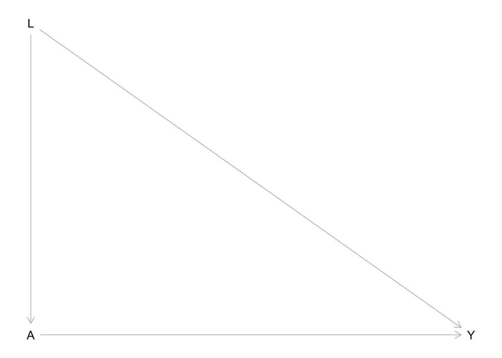

```r
library(dagitty)
g <- dagitty('dag{
  Y [pos = "1,1"]
  A [pos = "0,1"]
  L [pos = "0,0"]
  A -> Y
  L -> Y
  L -> A
 }')
plot(g)
```

またこのDAGをノンパラメトリック構造方程式モデルで示すと次のようになる．

$$\begin{eqnarray}
Y &=& f_Y(A,L,e_Y),\\
A &=& f_A(L,e_A),\\
L &=& f_L(e_L).\\
\end{eqnarray}$$

## 6.8 変数を条件付ける

変数を条件付けるとは，回帰モデルでは共変量としてモデルに投入すること（コントール），層別に分析を行うこと（クロス表，対数線形モデル），一部の集団にのみ分析すること（女性のみの分析），一部の集団にのみのデータを得て分析すること，その他，摩耗，脱落，無回答などがある．イメージしにくい場合は変数を$L=1$のようにある値に固定することを考えればよい．これは$L$に情報を与えているということになる．なお，DAGでは条件づけた場合は変数を$\fbox{L}$のように四角で囲む．

## 6.9 どのようにして関連は生まれるか

2変数の関連がどのようにして生じるのかを整理する．Elwert and Winship (2014) より，$A$と$B$に関連が生じるか，またそれは因果効果なのかをDAGから検討する．

### 6.9.1 連鎖経路（chains）

次のような場合，$A$と$Y$は関連する．

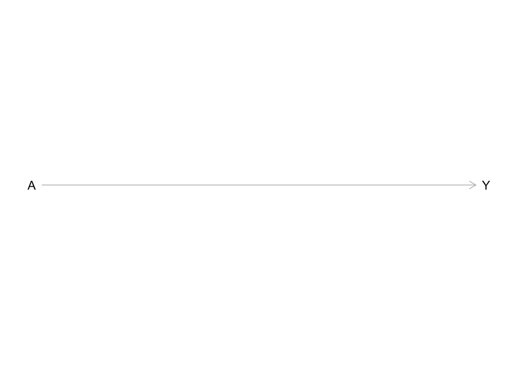

```r
g <- dagitty('dag{
  A [pos = "0,1"]
  Y [pos = "1,1"]
  A -> Y
 }')
plot(g)
```

$A$と$Y$の間に$M$のようなものがあっても$A$と$Y$は関連する．

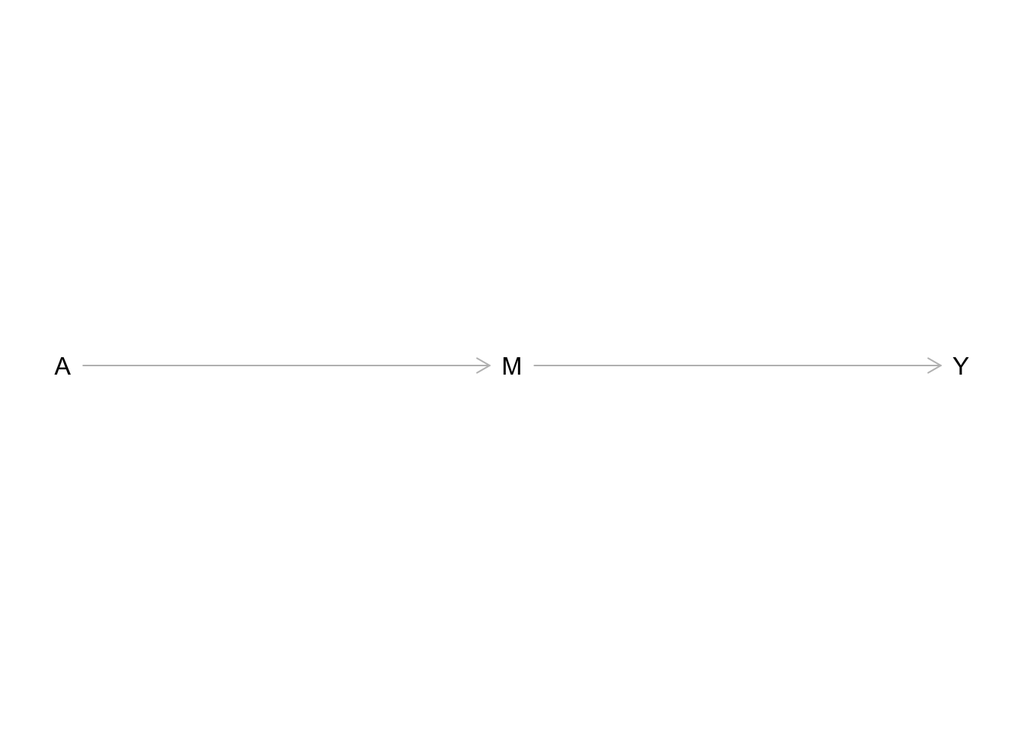

```r
g <- dagitty('dag{
  A [pos = "0,1"]
  Y [pos = "1,1"]
  M [pos = ".5,1"]
  A -> M -> Y
 }')
plot(g)
```

この場合$M$を条件付けない場合，$X$と$Y$は関連しており，もし他に非因果的経路がなければ，$A$は$Y$に因果的な効果を持つ（関連は因果）．しかし，$M$を条件付けると，$A$と$Y$は独立している（条件付き独立）．したがって，$M$を条件付けると，$A$は$Y$に因果的な効果がないという結論を導いてしまう．これはバッドコントロールや過剰統制バイアス（overcontrol bias）と呼ばれる．

したがって$M$は条件付けないのがよい（過剰統制バイアス）．

### 6.9.2 分岐経路（forks）

次のような場合，$A$と$Y$の間には矢線はないが，$A$と$Y$は$L$を通じて関連する．

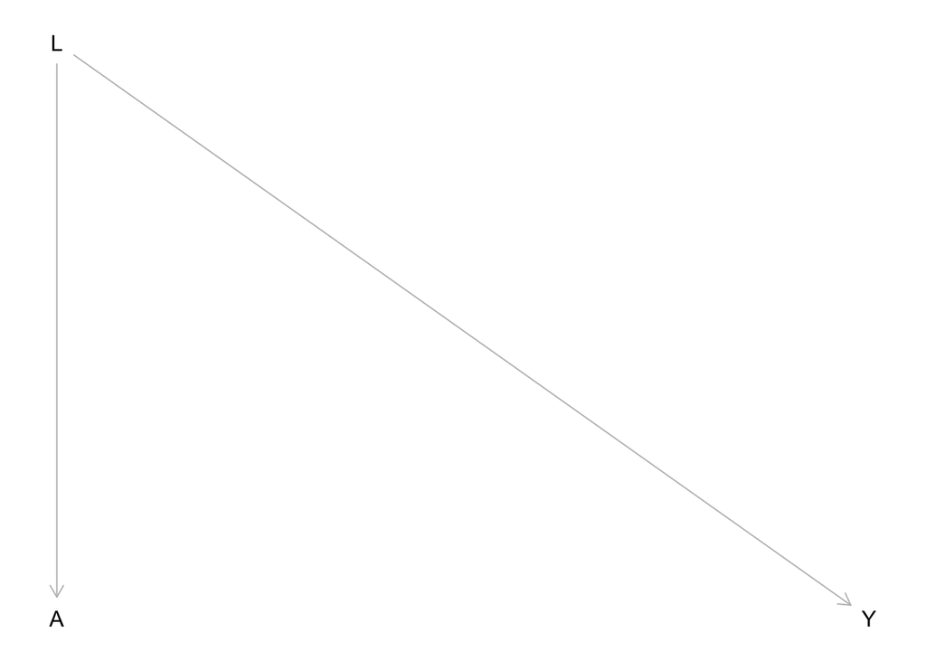

```r
g <- dagitty('dag{
  A [pos = "0,1"]
  Y [pos = "1,1"]
  L [pos = "0,0"]
  L -> A
  L -> Y
 }')
plot(g)
```

$L$を条件付けない場合，$A$と$Y$は$A\leftarrow L \rightarrow Y$という非因果的経路で関連するが，処置からアウトカムへの逆向きの流れの矢線を含んだ経路であるため$A$と$Y$の間に因果効果はない（関連は因果ではない）．$L$を条件付けた場合，$A$と$Y$は独立している（条件付き独立）．関連もなく因果効果もない．

したがって$L$は条件付けたほうがよい（交絡バイアス）．

### 6.9.3 逆分岐経路（inverted-forks）

合流経路とも呼ばれる．次のような場合，$A$と$Y$は関連しない．

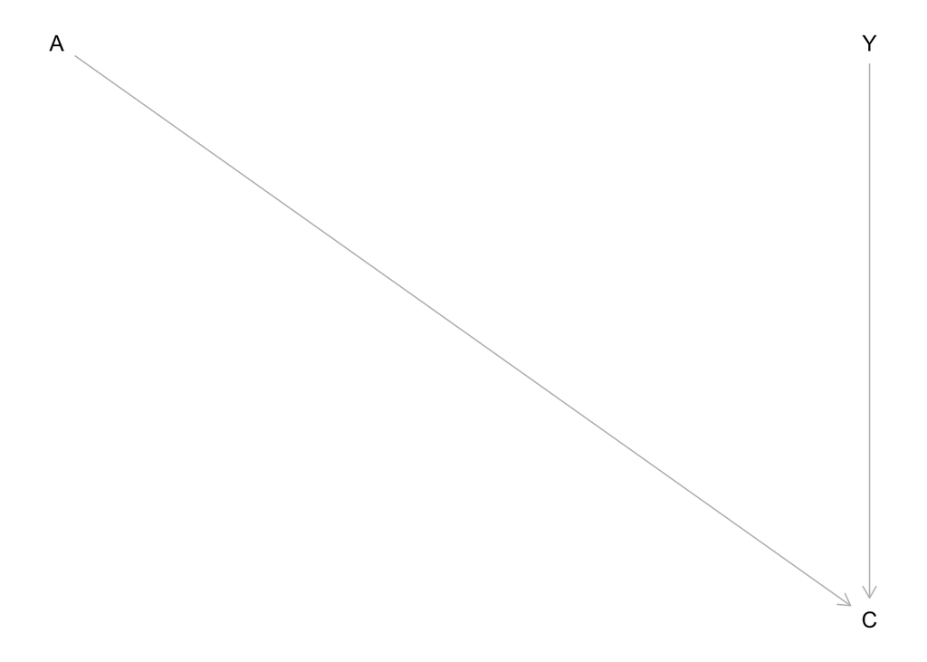

```r
g <- dagitty('dag{
  A [pos = "0,1"]
  Y [pos = "1,1"]
  C [pos = "1,2"]
  A -> C
  Y -> C
 }')
plot(g)
```

$C$を条件付ない場合，$A$と$Y$は独立している（関連もなく因果関係もない）．しかし，$C$を条件付けた場合，$A$と$Y$は関連するが，処置からアウトカムへの逆向きの流れの矢線を含んだ経路であるため因果的な関係はない（関連は因果ではない）．

さらに次のような例を考える．

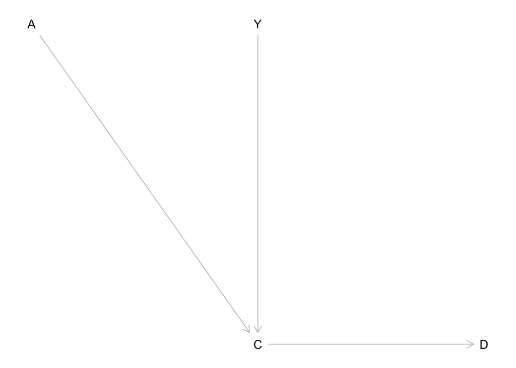

```r
g <- dagitty('dag{
  A [pos = "0,1"]
  Y [pos = "1,1"]
  C [pos = "1,2"]
  D [pos = "2,2"]
  A -> C
  Y -> C
  C -> D
 }')
plot(g)
```

$C$も$D$も条件付けない場合，$A$と$Y$は独立している．しかし，$C$または$D$を条件付けた場合，$A$と$Y$は関連するが，因果的な関係はない．

このような$C$を$A$と$Y$の合流点（collider）と呼ぶ．合流点や合流点の子孫を条件付けることによって生じる非因果的関連がもたらす因果効果へのバイアスを，合流点バイアスと呼ぶ．

したがって$C$や$D$は条件付けないほうがよい（合流点バイアス）．

## 6.10 有向分離

$Z$を与えた時に$A$と$Y$が独立となる（関連がない）となるためには，$A$と$Y$との間の経路を$Z$がブロックするかどうかを考える．そのような経路が$Z$によって有向分離（d-separation）あるいはブロックされるのは次の場合である．

$A$と$Y$を結ぶ経路について，$A$と$Y$が$Z$によって有向分離であるとは，（1）$A$と$Y$を結ぶ経路にある合流点でない変数（連鎖や分岐の中心にある変数）が$Z$に含まれている，あるいは（2）$A$と$Y$を結ぶ経路にある合流点変数とその子孫の中に$Z$に含まれないものがある．

次のようなDAGを考える．

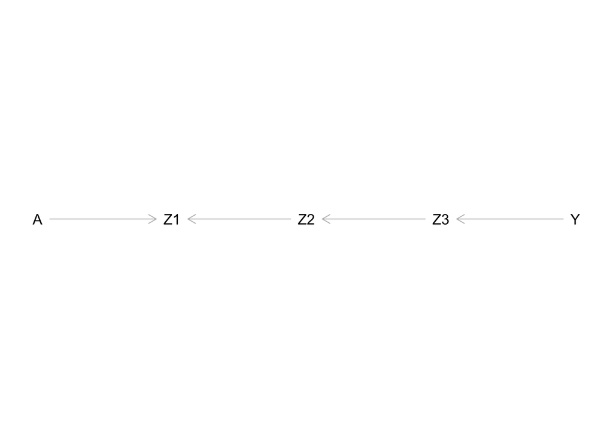

```r
g <- dagitty('dag{
  A [pos = "1,1"]
  Y [pos = "5,1"]
  Z1 [pos = "2,1"]
  Z2 [pos = "3,1"]
  Z3 [pos = "4,1"]
  A -> Z1 <- Z2 <- Z3 <- Y
 }')
plot(g)
```

例えば空集合を考えると$Z_1$という合流点が空集合には含まれていないので，（1）は満たさないが（2）を満たすため空集合は$A$と$Y$を有向分離する．$\{Z_1\}$は$Z_1$が唯一の合流点であり（1）も（2）も満たさないため，有向分離しない．（c）$\{Z_2\}$や$\{Z_3\}$は（1）も（2）も満たす．（e）$\{Z_1,Z_2\}$，$\{Z_1,Z_3\}$，$\{Z_1,Z_2,Z_3\}$は（2）は満たさないが（1）を満たすため有向分離する．

有向分離でない場合は，有向結合（d-connected）と呼ぶ．有向分離であれば2変数は統計的に独立であり，有向結合であれば2変数は関連している．有向分離された経路はブロックされた経路とも呼ばれ，関連を生み出さない．有向結合された経路はブロックされていない経路とも呼ばれ，関連を生み出す．

もし$A$と$Y$を結ぶある経路が合流点を含んでいなければ，経路にある変数について何も条件付けない場合，その経路は開いてる．これはunconditional d-connected（条件なし有向結合）である．この場合，もし経路にある合流点でない変数を条件付ければ，経路は閉じられる．これはconditional d-separated（条件付き有向分離）である．

もし$A$と$Y$を結ぶある経路が合流点を含んでいれば，経路にある変数について何も条件付けない場合，その経路は閉じている．これはunconditional d-separation（条件なし有向分離）である．この場合，もし経路にある合流点変数を条件付ければ，経路は開かれる． これはconditional d-connected（条件付き有向結合）である．

## 6.11 例題

例題1：$A$と$Y$が関連しないのは${M_1,M_2,M_3}$のどれを条件付けた場合か．すべて答えよ．

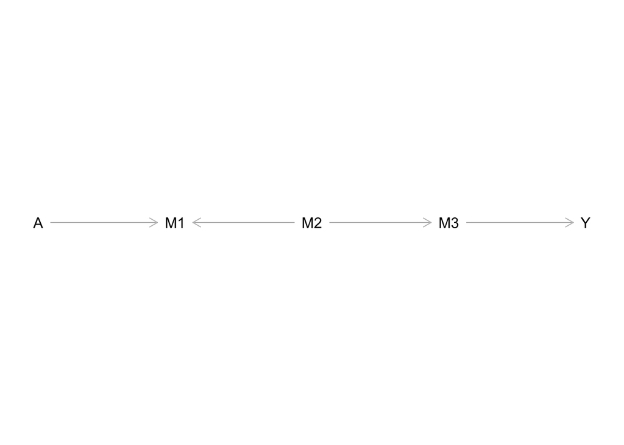

```r
g <- dagitty('dag{
  A -> M1 <- M2 -> M3 -> Y
 }')
coordinates(g) <-
    list(x=c(A=1, M1=2, M2=3, M3=4, Y=5),
         y=c(A=0, M1=0, M2=0, M3=0, Y=0))
plot(g)
```

例題2：$A$と$Y$が関連しないのは${M_1,M_2,M_3}$のどれを条件付けた場合か．すべて答えよ．

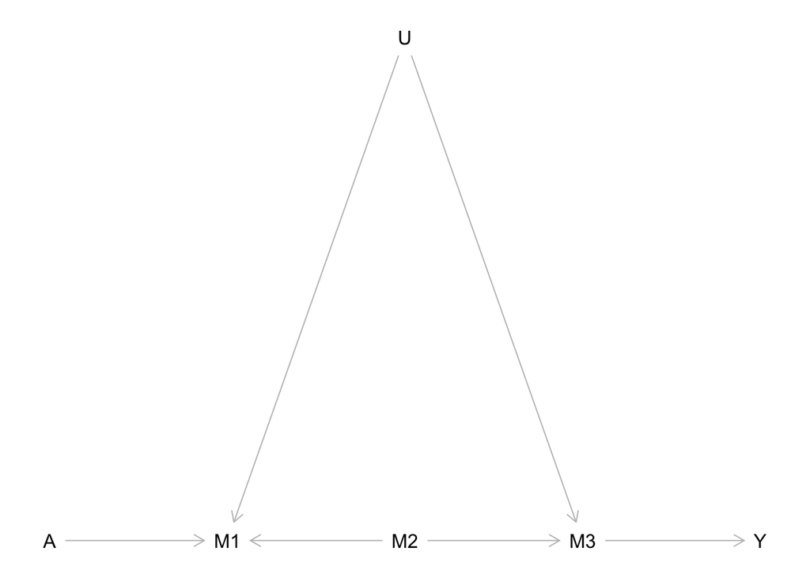

```r
g <- dagitty('dag{
  A -> M1 <- M2 -> M3 -> Y
  M1 <- U -> M3
 }')
coordinates(g) <-
    list(x=c(A=1, M1=2, M2=3, U = 3, M3=4, Y=5),
         y=c(A=0, M1=0, M2=0, U = -1, M3=0, Y=0))
plot(g)
```

例題3：$L$は$A$や$Y$よりも時間的に前にある変数である．また$U1$と$U2$は観察することができず，条件付けることができない．この場合，$L$を条件付けるとどのようなことが生じるだろうか．

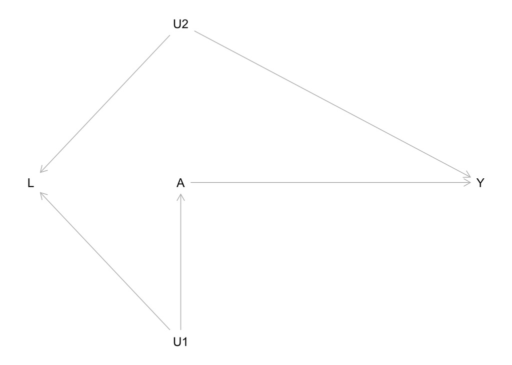

```r
g <- dagitty('dag{
  A <- U1 -> L <- U2 -> Y
  A -> Y
 }')
coordinates(g) <-
    list(x=c(A = 1, L = 0.5, Y = 2, U1 = 1, U2 = 1),
         y=c(A = 0, L = 0, Y = 0, U1 = 1, U2 = -1))
plot(g)
```

# 7 DAGから因果効果を識別する

## 7.1 バックドア基準

基本的には処置$A$の親について調整すれば因果効果を求めることができる．しかし，処置$A$の親についての情報が得られない場合もある．その場合は，別の変数について調整を行う必要がある．

次のようなバックドア基準を満たす変数について調整すれば，因果効果を求めることができる．処置$A$に伸びている矢線からはじまるアウカトム$Y$への経路をバックドアパス（back-door paths）と呼ぶ．バックドアパスは非因果的経路であり，その経路にあり$A$の子孫でない変数を条件付けることで，すべてのバックドアパスを閉じることができれば，因果効果を識別でき，標準化によって平均処置効果を求めることができる．

$$E[Y^a] = \sum_l E[Y|A=a,L=l]\Pr[L=l].$$

例えば次のDAGの場合，$A \leftarrow L_1 \leftarrow L_2 \rightarrow L_3 \rightarrow Y$はバックドアパスである．バックドアを閉じるためには，$\{L_1,L_2,L_3\}$のいずれかを条件付ければよい．$A$の親である$L_1$（常にバックドア基準を満たす）を調整する以外にも，因果効果を識別する方法があるのである．

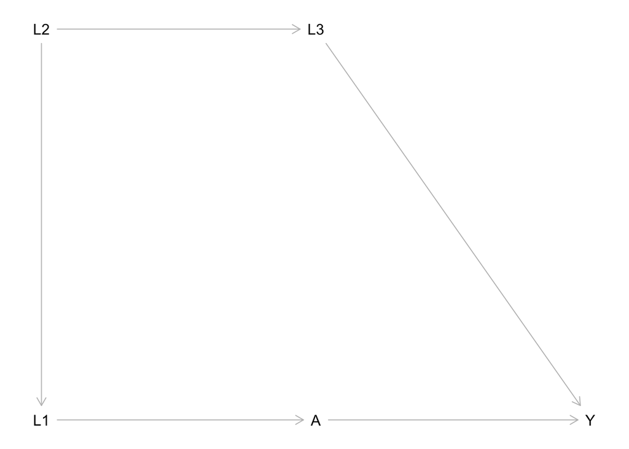

```r
g <- dagitty('dag{
  A -> Y
  L1 -> A
  L2 -> L1
  L2 -> L3
  L3 -> Y
 }')
coordinates(g) <-
    list(x=c(A = 1, Y = 2, L1 = 0, L2 = 0, L3 = 1),
         y=c(A = 1, Y = 1, L1 = 1, L2 = 0, L3 = 0))
plot(g)
```

実際にこれらを条件付ける方法としては標準化，IPTW，回帰モデル，マッチングが行われる． 標準化や回帰モデルの場合はアウトカム$Y$についてのモデルを考えるので，$L3$を共変量として投入して条件付ける$Y=\beta_0 + \beta_1A + \beta_2L_3$．IPTWやマッチングの場合は，処置$A$についてのモデルを考える（${\rm logit}[\Pr(A=1)]= \beta_0+\beta_1L_1$，$PS=\Pr[A=1|L_1]$）．

しかし，測定の誤差があったり，バックドアをブロックするための変数が含まれていなかったり，また誤った関数形が用いられているかもしれない．アウトカムモデルと処置モデルの両方を考慮した二重にロバストな推定（doubly robust estimation）がある．アウトカムモデルと処置モデルのどちらかのモデルが正しければ，バイアスのない因果効果を求めることができる．

例えば次のような方法がある．（1）傾向スコアマッチングを行い，マッチされたデータでさらに回帰分析を行う，（2）処置と$L_3$を含めた回帰分析を逆確率重み付け（IPTW）を用いて行う，など．様々な方法が考案されているが基本的な発想は同じである．

では次の場合はどうだろうか．

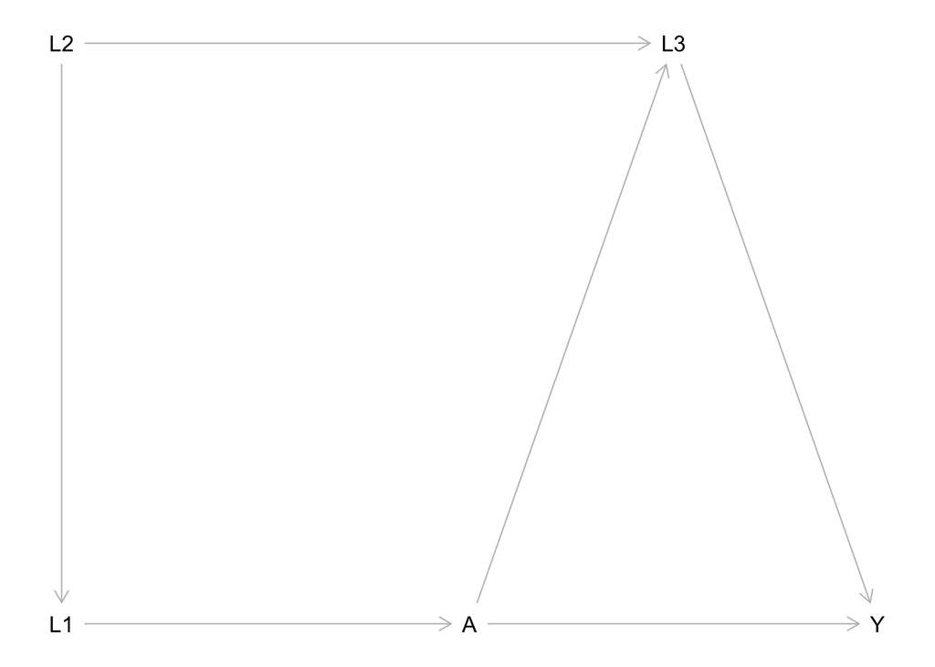

```r
g <- dagitty('dag{
  A -> Y
  L1 -> A
  L2 -> L1
  L2 -> L3
  L3 -> Y
  A -> L3
 }')
coordinates(g) <-
    list(x=c(A = 1, Y = 2, L1 = 0, L2 = 0, L3 = 1.5),
         y=c(A = 1, Y = 1, L1 = 1, L2 = 0, L3 = 0))
plot(g)
```

$A \leftarrow L_1 \leftarrow L_2 \rightarrow L_3 \rightarrow Y$はバックドアパスである．$L_3$は$A$の子孫であるため，バックドアを閉じるためには，$\{L_1,L_2\}$のいずれかを条件付ければよい． $A \rightarrow L3 \rightarrow Y$は総因果効果に含まれるので$\{L_3\}$を条件付けると過剰統制バイアスとなる．

なお，$A$の子孫に$W$があった場合でも$A$や$Z$によって$W$と$Y$の経路が有向分離されている場合もある．つまりバックドア基準を満たしていないが因果効果が識別可能な場合がある（拡張バックドア基準）．

# 8 回帰分析は何をやっているのか

もう一度次のような場合を考える．

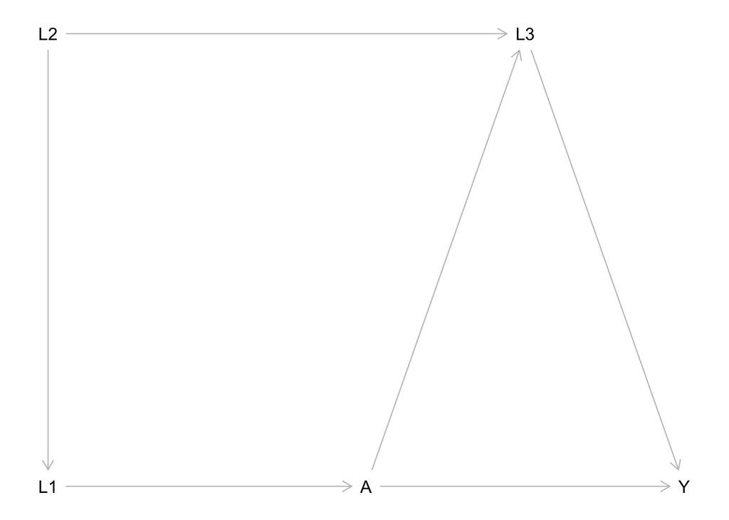

```r
g <- dagitty('dag{
  A -> Y
  L1 -> A
  L2 -> L1
  L2 -> L3
  L3 -> Y
  A -> L3
 }')
coordinates(g) <-
    list(x=c(A = 1, Y = 2, L1 = 0, L2 = 0, L3 = 1.5),
         y=c(A = 1, Y = 1, L1 = 1, L2 = 0, L3 = 0))
plot(g)
```

ここに登場するすべての変数を用いて回帰分析を行う．

$$Y = \beta_0 + \beta_1A + \beta_2L_1 + \beta_3L_2 + \beta_4L_3 + \epsilon$$

実際には次のようなことを行っているかもしれないが，それぞれの係数の解釈は異なる．

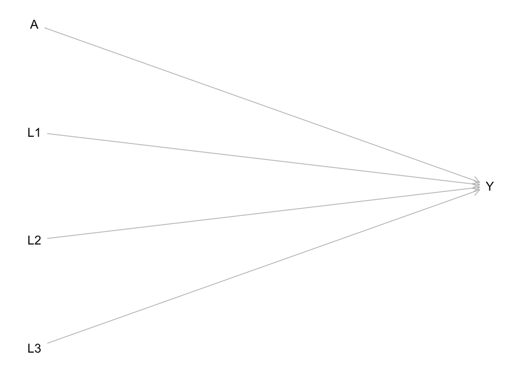

```r
g <- dagitty('dag{
  A -> Y
  L1 -> Y
  L2 -> Y
  L3 -> Y
 }')
coordinates(g) <-
    list(x=c(A = 1, Y = 2, L1 = 1, L2 = 1, L3 = 1),
         y=c(A = 1, Y = 2.5, L1 = 2, L2 = 3, L3 = 4))
plot(g)
```

- $\beta_1$は$A$が$Y$に与える因果効果と解釈できるか．
- $\beta_2$は$L_1$が$Y$に与える因果効果と解釈できるか．
- $\beta_3$は$L_2$が$Y$に与える因果効果と解釈できるか．
- $\beta_4$は$L_3$が$Y$に与える因果効果と解釈できるか．

以上のような問題があるため，回帰分析によって因果分析を行いたければ，まず因果効果を求めたい$A$と$Y$に焦点を絞り，そしてどのような変数を条件付ければよいかをDAGによって確認するのがよい．

もちろん回帰分析によって直接因果効果にアプローチすることも可能である．しかしそこで得られる値は，標準化やIPTWによるものと異なる場合がある． 例えば，次のような構造モデルを考える．

$$E[Y^a|L] = \beta_0 + \beta_1a + \beta_2aL + \beta_3L$$

$$\begin{eqnarray}
E[Y^1|L] -E[Y^0|L] &=&(\beta_0 + \beta_1 + \beta_2L + \beta_3L) - (\beta_0+ \beta_3L) \\
&=& \beta_1 + \beta_2L.
\end{eqnarray}$$

ここで，条件付き交換可能性，正値性，一致性が成り立っているのであれば， 反実仮想的な平均アウトカムは次の平均アウトカムと一致する．

$$E[Y|A,Z] = \alpha_0 + \alpha_1A + \alpha_2AL + \beta_3L$$

よって，先ほどの構造モデルのパラメータは，このアウトカム回帰モデルを用いて推定できる．ただし求められるのは条件付きの周辺期待値$E[Y^a|L]$についての$a$であり，$E[Y^a]$そのものではない．

$L$が交絡の調整に十分であれば，以上のモデルは$L$の層別に因果効果を推定することによって交絡を調整しており，条件付き処置効果を推定することができる．最小二乗推定量では，共変量特有の処置効果（covariate-specific treatment effect）の条件付き分散加重が用いられている (Angrist 1998, p 256; Morgan and Winship 2014, 206)．他にも Elwert and Winship (2010)，Aronow and Samii (2016) なども参照．

例えば$L = 1,2,3$であれば，

$$\frac{{\rm Var}[A|L=1]\Pr[L=1]}{\sum_z {\rm Var}[A|L=l]\Pr[L=l]}\left\{E[Y|A=1,L=1] - E[Y|A=0,L=1]\right\}$$

$$\frac{{\rm Var}[A|L=2]\Pr[L=2]}{\sum_z {\rm Var}[A|L=l]\Pr[L=l]}\left\{E[Y|A=1,L=2] - E[Y|A=0,L=2]\right\}$$

$$\frac{{\rm Var}[A|L=3]\Pr[L=3]}{\sum_z {\rm Var}[A|L=l]\Pr[L=l]}\left\{E[Y|A=1,L=3] - E[Y|A=0,L=3]\right\}$$

という3つの共変量特有の平均処置効果{E[Y|A=1,Z=z] - E[Y|A=0,Z=z] }（$z = 1, 2, 3$）に重み$\frac{{\rm Var}[A|Z=z]\Pr[Z=z]}{\sum_Z {\rm Var}[A|Z=z]\Pr[Z=z]}$（$z = 1, 2, 3$）をかけたものを足したものとなる．

これは次のような因果効果とは異なる．

$$\sum_z \left\{E[Y|A=1,L=l]- E[Y|A=0,L=l]\right\}\Pr[L=l]$$

回帰分析から直接因果効果にアプローチしたい場合は，交互作用を含めた柔軟なアウトカムのモデリングを行い，標準化を行う必要がある．この回帰分析+標準化の方法は，処置モデルによる傾向スコアを用いる方法とあわせて2重にロバストな推定の重要な要素である．

## 8.1 回帰分析のパラメータが平均処置効果と同じになる場合

次のようにアウトカムについてのモデルが交互作用項を含まない，$A$の係数が$L$によって同質であるというモデルを考える．

$$E[Y|A=a,L=l] = \beta_0 + \beta_1 A + \beta_2L$$

このような$A$の係数について同質的なアウトカムモデルを考えた時に，$A=a+1$とした場合は次のように標準化の式を変形することができる．

$$\begin{eqnarray}
\sum_lE[Y|A=a + 1,L=l]\Pr[L=l]
&=& \sum_l[\beta_0 + \beta_1 (a + 1) + \beta_2l]\Pr[L=l]\\
&=& \sum_l \beta_1 \Pr[L=l] + \sum_l E[\beta_0 + \beta_1a + \beta_2l]\Pr[L=l]\\
&=& \beta_1 \sum_l \Pr[L=l] + \sum_lE[Y|A=a,L=l]\Pr[L=l]\\
&=& \beta_1 + \sum_lE[Y|A=a,L=l]\Pr[L=l]
\end{eqnarray}$$

最後の式の第2項目は$A=a$の場合の標準化である．よって次のようになり， $A$が1単位変化した場合の標準化差は係数$\beta_1$と一致する．

$$\begin{eqnarray}
\sum_lE[Y|A=a + 1,L=l]\Pr[L=l] - \sum_lE[Y|A=a,L=l]\Pr[L=l] = \beta_1
\end{eqnarray}$$

以上のような強い仮定の場合には，$\Pr[L=l]$による重み付けがなくとも，係数$\beta_1$を標準化差として解釈できる．問題はこのような強い仮定が成り立っていることは理論的にも経験的にもなさそうであり，平均処置効果にバイアスが生じる可能性がある．

# 9 何を共変量として調整すればよいか

DAGのようなさまざまな変数の構造に関する詳細な情報がない場，他のアプローチを使用する必要がある．

伝統的な方法では交絡要因は次のように定義されている (Hernán and Robins 2020)． （1）処置変数と関連しており， （2）処置変数を条件づけた時にそれはアウトカムと関連しており，そして （3）処置とアウトカムの間の因果的な経路（causal path）の間にはない．

また次のような方針もある．

（4）処置後の変数は統制すべきでない．

しかし，処置後の変数であっても，統制したほうが良い場合がある．例えば次の例では，$Z$は処置$A$の後にある．しかし$A\leftarrow U \rightarrow Z \rightarrow Y$という$A$と$Y$の間に非因果的なパスが開いている．$U$から$A$に矢線が伸びているので，これもバックドアパスである．このような場合は，$Z$を統制し，非因果的なパスを閉じる必要がある．

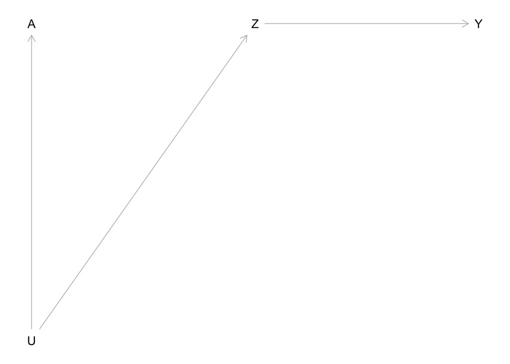

処置前の変数であっても，統制しないほうが良い場合がある（Mバイアス）．

処置前であるとか処置後という時間的な基準によって共変量を選択するのではなく，DAGによってDGPを検討した上で統制すべきかすべきでないかを判断する必要がある．なお，データから統計的に有意な関連があるあるいは関連がないという選択基準は用いるべきではない．

例えば次のような場合，$Z$は従来の交絡要因の条件を満たしてはいるものの，$Z$を統制することは，閉じられていた$A \rightarrow Z \leftarrow U$という経路を開き，結果として$A \rightarrow Z \leftarrow U \rightarrow Y$という経路を開いてしまうことで，$A$と$Y$に非因果的な関連を生み出してしまう (Hernán and Robins 2020)．

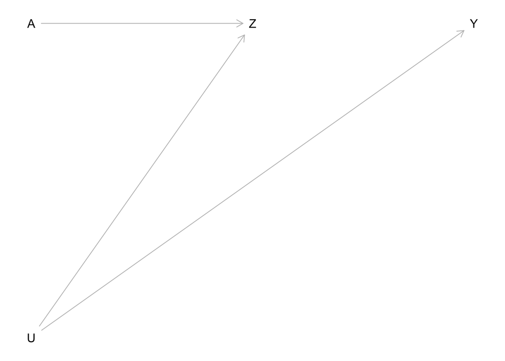

ここで$Z$が$A$に影響を与えているという場合，$Z \rightarrow A$という直接矢線で結びついている場合だけではなく，$Z \rightarrow W \rightarrow A$といったような有向パスによって結びついている場合も含む．つまり処置と結果に共通する先祖（ancestor）を特定する．

操作変数とは処置$A$に影響を与えることを通じてのみアウトカム$Y$に影響を与える変数であり，これを統制することは，$A$と$Y$の交絡を取り除くことに失敗するだけでなく，バイアスを大きくすることにつながる可能性がある (Hernán and Robins 2020; Cinelli, Forney, and Pearl 2021, april)．これは$Z$バイアスと呼ばれる (Hernán and Robins 2020)．操作変数についてはこのような問題があるものの，操作変数法は因果効果を求める上での強力な武器である．

Cinelli, Forney, and Pearl (2021, april) でもよい統制変数（good control）と悪い統制変数（bad control）に分けて議論している．回帰式に統制変数を追加すると，関心のある回帰係数とその係数が示すべき効果との間に意図しない不一致が生じることがある．例えば，統制変数を追加することで，求めたい効果に近づけるどころか，かえってよりバイアスを生み出したりそれを大きくしてしまうことがある．こういった不一致の原因を体系的に理解するためにDAGが用いられ，統制すべき場合と統制すべきでない場合の例が複数示されている．

DAGsやその他の基準による共変量の選択は因果効果を識別するためには必要不可欠である．この共変量の選択は決して統計モデルや統計的関連の有無をベースに行っていないことに注意が必要である．専門的な知識，理論的考察，先行研究などをもとに，データ生成過程をDAGなどで示し，因果効果を識別するための条件を探ることは，洗練された統計モデルの適用とは無関係である．

つまり，因果推論の中心にあるのは，観察データに対する統計モデルから直接因果関係を明らかにすることではなく，妥当な仮定に基づき関連を因果関係として扱うことができるかどうかを理論的に検討することである．

# 10 バランス

処置を受けた集団と処置を受けなかった集団の間で共変量の分布が類似していることをバランスがとれているという．ランダム化実験では，観察された共変量のバランスがとられているだけではなく，観察されない共変量のバランスもとる．

IPTWやマッチングによって観察データの因果推論を行う場合，処置変数によって共変量のバランスがとられているのかを確認することが多い．図によってバランスがとられているかを確認することも可能であるが，標準化された差（standardized difference）によって数値で平均値についてバランスがとれているのかを確認することもできる (Austin 2011)．

$$d = \frac{\bar x_{\rm treatment} - \bar x_{\rm control}}{\sqrt{\frac{s^2_{\rm treatment}+s^2_{\rm control}}{2}}}$$

ここで$\bar x_{\rm treatment}$と$\bar x_{\rm control}$はそれぞれ処置を受けた集団と処置を受けなかった集団の共変量の平均値を，$s^2_{\rm treatment}$と$s^2_{\rm control}$は標本分散を示す． 絶対的な基準はないものの，この値が0.1より小さければ平均値について十分にバランスがとれているとみなされることが多い (Austin 2011)．

# 11 Rによる分析

## 11.1 準備

```r
pacman::p_load(tidyverse,
               estimatr,
               WeightIt,
               cobalt,
               skimr,
               marginaleffects)
```

次のようなDAGに基づきシミュレーションデータを作成する．

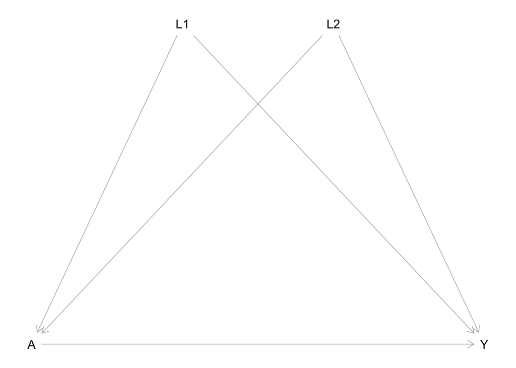

この場合，$L_1$と$L_2$を条件付ければ因果効果が識別できる．

## 11.2 データ（L1とL2が2値変数）

```r
## setting 1: L1 and L2 are binary variables
n <- 100000
set.seed(123456)
L1 <- rbinom(n, size = 1, prob = .4)
L2 <- rbinom(n, size = 1, prob = .7)
PS <- 1/(1 + exp(-1 -.3*L1 + 1*L2 + 1*runif(n)))
A <- rbinom(n, size = 1, prob = PS)
Y0 <- 100 + 5*L1 + 1*L2 + rnorm(n, mean = 0, sd = 4)
tau <- rnorm(n, mean = 5, sd = 1)
Y1 <- 102 + 2*L1 + 3*L2 + tau + rnorm(n, mean = 0, sd = 4)
tau <- Y1 - Y0
Y <- A * Y1 + (1 - A) * Y0
d <- tibble(Y1,Y0,tau,A,Y,PS,L1,L2)
```

$ATE$，$ATT$，$ATC$は次のようになる（`tau`の列）．

```r
## ATE
ate <- d |>
  summarise(across(everything(), mean))
ate |>
  kable(format = "simple")
```

[output not shown]

```r
## ATT and ATC
att_atc <- d |>
  group_by(A) |>
  summarise(across(everything(), mean))
att_atc |>
  kable(format = "simple")
```

| A | Y1 | Y0 | tau | Y | PS | L1 | L2 |
| --- | --- | --- | --- | --- | --- | --- | --- |
| 0 | 110.0837 | 102.6218 | 7.461970 | 102.6218 | 0.4467475 | 0.3666737 | 0.7919553 |
| 1 | 109.6513 | 102.7549 | 6.896323 | 109.6513 | 0.5162479 | 0.4345075 | 0.5983797 |

$ATE=$ 7.1910761，$ATT＝$ 6.8963232，$ATC=$ 7.4619699．

## 11.3 標準化

いま$L1$と$L2$は2値変数なので，次のように標準化平均を求める．

$$E[Y^a] = \sum_{l1, l2} E[Y|A=a,L_1=l_1,L_2=l_2]\Pr[L_1=l_1,L_2=l_2].$$

$L_1$と$L_2$別に集計を行い，さらに$A$と$L_1$と$L_2$別に集計を行う．

```r
tab_summary <- d |>
  mutate(sum = sum(n())) |>    # サンプルサイズを出しておく
  group_by(L1,L2) |>    # L1とL2別に集計
  mutate(n = n(),   # L1とL2の組み合わせの周辺確率を求める
         prob = n/sum) |>
  group_by(A,L1,L2) |>   # AとL1とL2別に集計
  dplyr::summarise(Mean = mean(Y),   # Yの平均値を求める　周辺確率を適当な関数で維持
                   prob = mean(prob)) |>
  ungroup() |>
  pivot_wider(id_cols = c(L1,L2,prob),   # ワイド形式に
              names_from = A,
              values_from = Mean,
              names_prefix = "Y") |>
  mutate(tau_L = Y1 - Y0,   # 平均処置効果を求める
         tau_L_prob = tau_L * prob)   # 平均処置効果のLの周辺確率で重み付け
tab_summary
```

```
# A tibble: 4 × 7
     L1    L2  prob    Y0    Y1 tau_L tau_L_prob
  <int> <int> <dbl> <dbl> <dbl> <dbl>      <dbl>
1     0     0 0.181  100.  107.  6.92      1.25
2     0     1 0.420  101.  110.  8.94      3.76
3     1     0 0.120  105.  109.  4.20      0.505
4     1     1 0.279  106.  112.  6.00      1.67
```

```r
tab_summary |>
  summarise(tau = sum(tau_L_prob)) |>　# 平均処置効果のLの周辺確率で重み付けたものをたす
  knitr::kable(format = "simple")
```

[output not shown]

スタックして求める方法は次のようになる．

```r
d_NA <- d |>
  dplyr::select(A,Y,L1,L2)   # 変数を限定する
d_0 <- d_NA |>
  mutate(Y = NA,
         A = 0,
         treatment = 0)
d_1 <- d_NA |>
  mutate(Y = NA,
         A = 1,
         treatment = 1)
d_stacked <- bind_rows(d_NA, d_0, d_1)

fit <- d_stacked |> lm(Y ~ A * L1 * L2, data = _)

predicted_mean <- broom::augment(fit, newdata = d_stacked)
predicted_mean |> filter(treatment == 0)
```

```
# A tibble: 100,000 × 7
       A     Y    L1    L2 treatment .fitted .resid
   <dbl> <dbl> <int> <int>     <dbl>   <dbl>  <dbl>
 1     0    NA     1     1         0    106.     NA
 2     0    NA     1     1         0    106.     NA
 3     0    NA     0     0         0    100.     NA
 4     0    NA     0     1         0    101.     NA
 5     0    NA     0     1         0    101.     NA
 6     0    NA     0     1         0    101.     NA
 7     0    NA     0     1         0    101.     NA
 8     0    NA     0     1         0    101.     NA
 9     0    NA     1     1         0    106.     NA
10     0    NA     0     1         0    101.     NA
# ℹ 99,990 more rows
```

```r
predicted_mean |> filter(treatment == 1)
```

```
# A tibble: 100,000 × 7
       A     Y    L1    L2 treatment .fitted .resid
   <dbl> <dbl> <int> <int>     <dbl>   <dbl>  <dbl>
 1     1    NA     1     1         1    112.     NA
 2     1    NA     1     1         1    112.     NA
 3     1    NA     0     0         1    107.     NA
 4     1    NA     0     1         1    110.     NA
 5     1    NA     0     1         1    110.     NA
 6     1    NA     0     1         1    110.     NA
 7     1    NA     0     1         1    110.     NA
 8     1    NA     0     1         1    110.     NA
 9     1    NA     1     1         1    112.     NA
10     1    NA     0     1         1    110.     NA
# ℹ 99,990 more rows
```

```r
predicted_mean |>
  group_by(treatment) |>
  summarise(mean_Y = mean(.fitted)) |>
  pivot_wider(names_from = treatment, values_from = mean_Y) |>
  mutate(tau = `1` - `0`) |>
  knitr::kable(format = "simple")
```

| 0 | 1 | NA | tau |
| --- | --- | --- | --- |
| 102.69 | 109.8729 | 105.9883 | 7.182879 |

次のような方法のほうがイメージしやすいかもしれない．もとのデータについてすべて$A=0$としたデータを用いて$Y^0$を予測したものと，すべて$A=1$としたデータを用いて$Y^1$を予測したものを求め，その差の平均値を求める．

```r
Y0 <- predict(fit, newdata = d_NA |> mutate(A=0))
Y1 <- predict(fit, newdata = d_NA |> mutate(A=1))
mean(Y0);mean(Y1);mean(Y1-Y0)
```

```
[1] 102.69
```

```
[1] 109.8729
```

```
[1] 7.182879
```

この方法だと標準誤差が求められない．そこでデータから同じサンプルサイズを復元抽出でサンプリングしたブートストラップサンプルを作成する．今回は100個のブートストラップサンプルがあるが，最終的には1000にするなど十分に数を増やす．

```r
# 空のリストを作成
d_boot <- list()
set.seed(123456)
# リストの各要素にブートストラップを入れる
for (i in 1:100){
  d_boot[[i]] <- sample_n(d_NA,
                          size = nrow(d_NA),
                          replace = TRUE)
}
# 出来上がったデータのリストをくっつけてまとめる
d_boot <- d_boot |>
  bind_rows(.id = "boot") |>
  group_by(boot) |>
  nest()
d_boot
```

```
# A tibble: 100 × 2
# Groups:   boot [100]
   boot  data
   <chr> <list>
 1 1     <tibble [100,000 × 4]>
 2 2     <tibble [100,000 × 4]>
 3 3     <tibble [100,000 × 4]>
 4 4     <tibble [100,000 × 4]>
 5 5     <tibble [100,000 × 4]>
 6 6     <tibble [100,000 × 4]>
 7 7     <tibble [100,000 × 4]>
 8 8     <tibble [100,000 × 4]>
 9 9     <tibble [100,000 × 4]>
10 10    <tibble [100,000 × 4]>
# ℹ 90 more rows
```

```r
# それぞれのブートストラップサンプルに対して回帰分析をfit
# すべてをA=0としたデータとA=1としたデータを用いY0とY1を予測
d_boot <- d_boot |>
  mutate(fit = map(data, ~lm(Y ~ A * L1 * L2, data = .)),
         pred_Y0 = pmap(list(x = fit, y = data),
                        function(x, y)
                          predict(x,
                                  newdata = mutate(y, A = 0))),
         pred_Y1 = pmap(list(x = fit, y = data),
                        function(x, y)
                          predict(x,
                                  newdata = mutate(y, A = 1))),
         mean_Y0 = map_dbl(pred_Y0, mean),
         mean_Y1 = map_dbl(pred_Y1, mean),
         tau = mean_Y1 - mean_Y0)
d_boot
```

```
# A tibble: 100 × 8
# Groups:   boot [100]
   boot  data                   fit    pred_Y0 pred_Y1 mean_Y0 mean_Y1   tau
   <chr> <list>                 <list> <list>  <list>    <dbl>   <dbl> <dbl>
 1 1     <tibble [100,000 × 4]> <lm>   <dbl>   <dbl>      103.    110.  7.22
 2 2     <tibble [100,000 × 4]> <lm>   <dbl>   <dbl>      103.    110.  7.21
 3 3     <tibble [100,000 × 4]> <lm>   <dbl>   <dbl>      103.    110.  7.21
 4 4     <tibble [100,000 × 4]> <lm>   <dbl>   <dbl>      103.    110.  7.14
 5 5     <tibble [100,000 × 4]> <lm>   <dbl>   <dbl>      103.    110.  7.19
 6 6     <tibble [100,000 × 4]> <lm>   <dbl>   <dbl>      103.    110.  7.20
 7 7     <tibble [100,000 × 4]> <lm>   <dbl>   <dbl>      103.    110.  7.25
 8 8     <tibble [100,000 × 4]> <lm>   <dbl>   <dbl>      103.    110.  7.13
 9 9     <tibble [100,000 × 4]> <lm>   <dbl>   <dbl>      103.    110.  7.19
10 10    <tibble [100,000 × 4]> <lm>   <dbl>   <dbl>      103.    110.  7.15
# ℹ 90 more rows
```

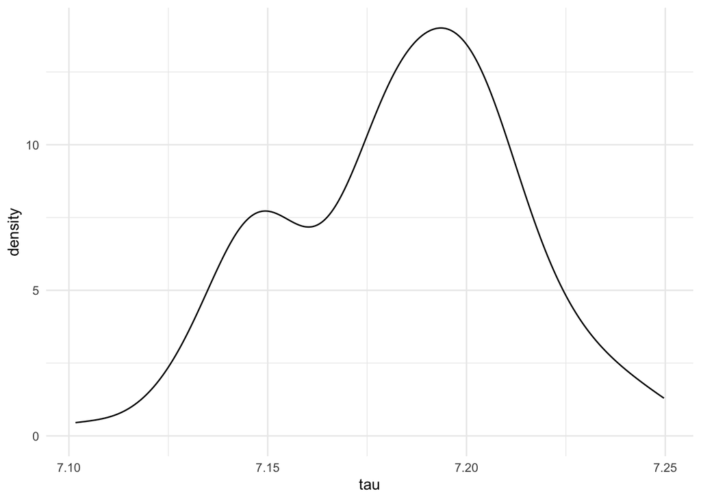

```r
d_boot |>
  ggplot(aes(x = tau)) +
  geom_density() +
  theme_minimal()
```

```r
d_boot |> pull(tau) |> mean()
```

```
[1] 7.183357
```

```r
d_boot |> pull(tau) |> sd()
```

```
[1] 0.02927351
```

```r
d_boot |> pull(tau) |> quantile(prob = c(0.025, 0.975))
```

```
    2.5%    97.5%
7.129404 7.235847
```

最後に限界効果を用いる．先ほどのブートストラップ標準誤差とほぼ同様の標準誤差が得られる．

```r
## marginal effects
fit <- lm_robust(Y ~ A * L1 * L2, data = d)
fit
```

```
               Estimate Std. Error     t value      Pr(>|t|)    CI Lower
(Intercept) 100.0730837 0.04779351 2093.863450  0.000000e+00 99.97940899
A             6.9205645 0.06184758  111.897094  0.000000e+00  6.79934396
L1            4.8164221 0.08108622   59.398776  0.000000e+00  4.65749415
L2            0.9215454 0.05389007   17.100467  1.825048e-65  0.81592152
A:L1         -2.7220773 0.10073056  -27.023351 2.972750e-160 -2.91950798
A:L2          2.0166413 0.07410626   27.212832 1.798415e-162  1.87139390
L1:L2         0.1794504 0.09082744    1.975729  4.818821e-02  0.00142975
A:L1:L2      -0.2196956 0.11916139   -1.843681  6.523264e-02 -0.45325041
               CI Upper    DF
(Intercept) 100.1667584 99992
A             7.0417850 99992
L1            4.9753501 99992
L2            1.0271693 99992
A:L1         -2.5246467 99992
A:L2          2.1618886 99992
L1:L2         0.3574711 99992
A:L1:L2       0.0138593 99992
```

```r
# ATE
comparisons(fit, variables = list(A = 0:1)) |> summary()
```

```
 Term          Contrast Estimate Std. Error   z Pr(>|z|) 2.5 % 97.5 %
    A mean(1) - mean(0)     7.18     0.0264 272   <0.001  7.13   7.23

Columns: term, contrast, estimate, std.error, statistic, p.value, conf.low, conf.high
```

```r
# ATTとATC
comparisons(fit, by = "A", variables = list(A = 0:1)) |> summary()
```

```
 Term          Contrast A Estimate Std. Error   z Pr(>|z|)   S 2.5 % 97.5 %
    A mean(1) - mean(0) 0     7.45     0.0269 277   <0.001 Inf  7.40   7.51
    A mean(1) - mean(0) 1     6.89     0.0272 253   <0.001 Inf  6.83   6.94

Columns: term, contrast, A, estimate, std.error, statistic, p.value, s.value, conf.low, conf.high, predicted_lo, predicted_hi, predicted
```

なお交絡要因の数が多い場合には，機械学習の方法を用いることができる．

## 11.4 IPTW

まずロジスティック回帰分析によって傾向スコアの予測値を求め，`est_PS`とする．これを用いて`W_ATE`，`W_ATT`，`W_ATC`という3つのウェイトを作成している．

```r
d_w <- d_NA |>
  glm(A ~ L1 * L2, family = binomial(link = "logit"), data = _) |>
  broom::augment(type.predict = "response", newdata = d_NA) |>
  rename(est_PS = .fitted) |>
  mutate(W_ATE = A/est_PS + (1-A)/(1-est_PS),
         W_ATT = A + (1-A)*est_PS/(1-est_PS),
         W_ATU = A*(1-est_PS)/est_PS + (1-A))
```

バランスされているかを確認する．これを用いて標準差を求めることもできる．

```r
d_w |>
  group_by(A) |>
  summarise(mean = mean(L1),
            var = var(L1),
            w_mean = sum(L1*W_ATE)/sum(W_ATE),
            w_var = sum(W_ATE*(L1-w_mean)^2)/sum(W_ATE)) |>
  kable(format = "simple")
```

| A | mean | var | w_mean | w_var |
| --- | --- | --- | --- | --- |
| 0 | 0.3666737 | 0.2322286 | 0.39916 | 0.2398313 |
| 1 | 0.4345075 | 0.2457159 | 0.39916 | 0.2398313 |

```r
d_w |>
  group_by(A) |>
  summarise(mean = mean(L2),
            var = var(L2),
            w_mean = sum(L2*W_ATE)/sum(W_ATE),
            w_var = sum(W_ATE*(L2-w_mean)^2)/sum(W_ATE)) |>
  kable(format = "simple")
```

| A | mean | var | w_mean | w_var |
| --- | --- | --- | --- | --- |
| 0 | 0.7919553 | 0.1647653 | 0.69925 | 0.2102994 |
| 1 | 0.5983797 | 0.2403265 | 0.69925 | 0.2102994 |

作成したウェイトを用いて回帰分析をおこなう．

```r
# ATE
d_w |>
  lm_robust(Y ~ A, weights = W_ATE, data = _)
```

```
              Estimate Std. Error   t value Pr(>|t|)   CI Lower   CI Upper
(Intercept) 102.690050 0.02128310 4824.9572        0 102.648335 102.731764
A             7.182879 0.02957036  242.9081        0   7.124921   7.240837
               DF
(Intercept) 99998
A           99998
```

```r
# ATT
d_w |>
  lm_robust(Y ~ A, weights = W_ATT, data = _)
```

```
              Estimate Std. Error   t value Pr(>|t|)   CI Lower   CI Upper
(Intercept) 102.764341 0.02323302 4423.2026        0 102.718805 102.809878
A             6.886914 0.03092342  222.7087        0   6.826305   6.947524
               DF
(Intercept) 99998
A           99998
```

```r
# ATC
d_w |>
  lm_robust(Y ~ A, weights = W_ATU, data = _)
```

```
              Estimate Std. Error   t value Pr(>|t|)   CI Lower   CI Upper
(Intercept) 102.621772 0.02056252 4990.7201        0 102.581469 102.662074
A             7.454887 0.02963713  251.5387        0   7.396798   7.512975
               DF
(Intercept) 99998
A           99998
```

`WeightIt`パッケージの`weightit`関数を用いて，ウェイトを作成してみる． `method = "glm"`とすることで一般化線形モデルによる傾向スコアの推定をおこなう．デフォルトのリンク関数はロジットであり，ロジスティクス回帰分析によって推定する．

```r
tm_fit_ate <- weightit(A ~ L1 * L2,
                       method = "glm",
                       link = "logit",
                       estimand = "ATE",
                       data = d_NA)
tm_fit_ate
```

```
A weightit object
 - method: "glm" (propensity score weighting with GLM)
 - number of obs.: 100000
 - sampling weights: none
 - treatment: 2-category
 - estimand: ATE
 - covariates: L1, L2
```

```r
summary(tm_fit_ate)
```

```
                 Summary of weights

- Weight ranges:

           Min                                  Max
treated 1.4571 |------------------|          2.6107
control 1.6208    |------------------------| 3.1877

- Units with the 5 most extreme weights by group:

             24     18      8      7      6
 treated 2.6107 2.6107 2.6107 2.6107 2.6107
             48     37     27     14     11
 control 3.1877 3.1877 3.1877 3.1877 3.1877

- Weight statistics:

        Coef of Var   MAD Entropy # Zeros
treated       0.220 0.202   0.025       0
control       0.243 0.185   0.027       0

- Effective Sample Sizes:

            Control  Treated
Unweighted 52109.   47891.
Weighted   49192.62 45686.62
```

```r
bal.tab(tm_fit_ate, stats = c("mean.diffs", "variance.ratios"),
        continuous = "std", binary = "std", un = TRUE)
```

```
Balance Measures
               Type Diff.Un V.Ratio.Un Diff.Adj V.Ratio.Adj
prop.score Distance  0.4539     1.4409        0           1
L1           Binary  0.1388          .       -0           .
L2           Binary -0.4301          .        0           .

Effective sample sizes
            Control  Treated
Unadjusted 52109.   47891.
Adjusted   49192.62 45686.62
```

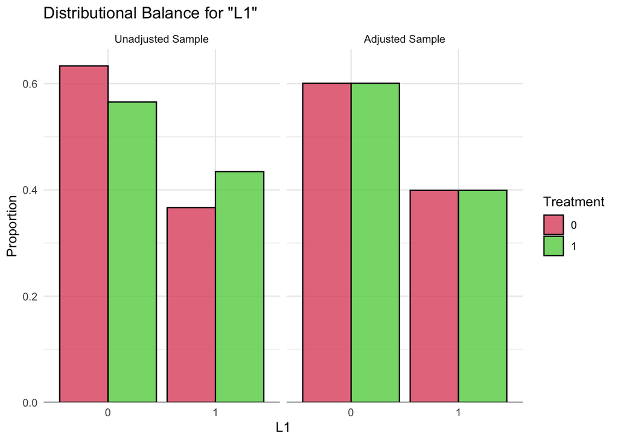

```r
bal.plot(tm_fit_ate, "L1", which = "both") +
  theme_minimal() +
  scale_fill_manual(values = 2:3)
```

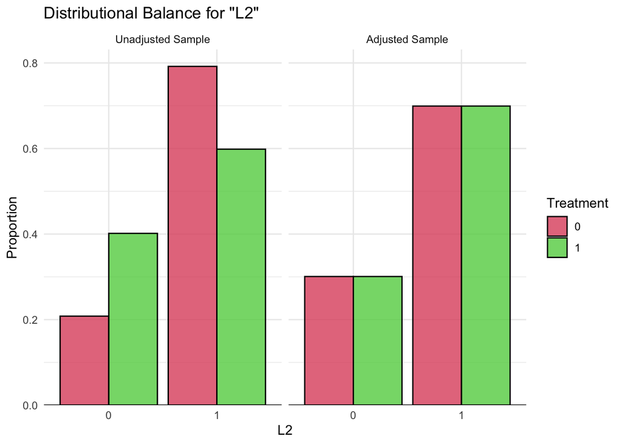

```r
bal.plot(tm_fit_ate, "L2", which = "both") +
  theme_minimal() +
  scale_fill_manual(values = 2:3)
```

ウェイトを取り出して，回帰分析を行う．

```r
# ウェイトをPS_ateという変数とする
d_w <- d_w |> mutate(PS_ate = tm_fit_ate$weights)
# ATE
d_w |>
  lm_robust(Y ~ A, weights = PS_ate,  data = _)
```

```
              Estimate Std. Error   t value Pr(>|t|)   CI Lower   CI Upper
(Intercept) 102.690050 0.02128310 4824.9572        0 102.648335 102.731764
A             7.182879 0.02957036  242.9081        0   7.124921   7.240837
               DF
(Intercept) 99998
A           99998
```

同様に`estimand = "ATT"`や`estimand = "ATC"`とすることで ウェイトを求めることができる．

```r
# ATT
tm_fit_att <- weightit(A ~ L1 * L2,
                       method = "glm",
                       link = "logit",
                       estimand = "ATT",
                       data = d_w)
# ATC
tm_fit_atc <- weightit(A ~ L1 * L2,
                       method = "glm",
                       link = "logit",
                       estimand = "ATC",
                       data = d_w)
```

また一般化線形モデル以外にも様々な傾向スコアやウェイトを求める方法がある．詳しくは`WeightIt`のヘルプを参照．

| method | 内容 |
| --- | --- |
| `glm` | Propensity score weighting using generalized linear models. |
| `gbm` | Propensity score weighting using generalized boosted modeling. |
| `cbps` | Covariate Balancing Propensity Score weighting. |
| `npcbps` | Non-parametric Covariate Balancing Propensity Score weighting. |
| `ebal` | Entropy balancing. |
| `optweight` | Optimization-based weighting. |
| `super` | Propensity score weighting using SuperLearner. |
| `bart` | Propensity score weighting using Bayesian additive regression trees (BART). |
| `energy` | Energy balancing. |

例えば，Hainmueller (2012) によって開発されたエントロピーバランシング（`ebal`）では平均値について完全にバランスされる．またばらつきについてもバランスされるように指定することもできる．

例えば，複数の機械学習モデルの最適な加重平均（アンサンブル）を用いるSuperLearnerを使用することもできる（`method = super`を設定し，`SL.library`でいくつかの機械学習モデルを選ぶ）．

## 11.5 データ（L1とL2が連続変数）

L1とL2が連続変数の場合のデータを次のように作成する．

```
   Min. 1st Qu.  Median    Mean 3rd Qu.    Max.
0.01313 0.14527 0.21360 0.23453 0.30391 0.87296
```

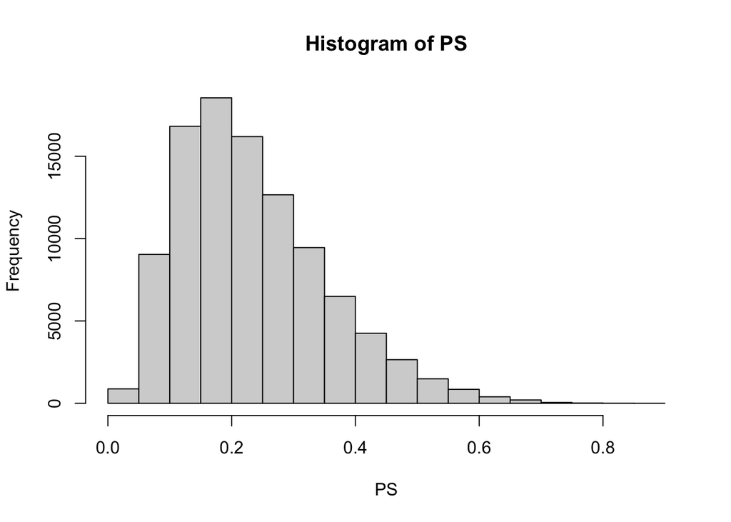

```r
## setting 2: L1 and L2 are continuous variables
n <- 100000
L1 <- rnorm(n, mean = 1, sd = 1)
L2 <- rnorm(n, mean = 5, sd = 3)
PS <- 1/(1 + exp( -.2*L1 + .2*L2 + 1*runif(n)))
summary(PS);hist(PS)
```

```r
A <- rbinom(n, size = 1, prob = PS)
Y0 <- 100 + 5*L1 + 1*L2 + rnorm(n, mean = 0, sd = 4)
tau <- rnorm(n, mean = 5, sd = 1)
mean(tau)
```

```
[1] 5.0007
```

```r
Y1 <- 102 + 2*L1 + 3*L2 + tau + rnorm(n, mean = 0, sd = 4)
tau <- Y1 - Y0
Y <- A * Y1 + (1 - A) * Y0
d <- tibble(Y1,Y0,tau,A,Y,PS,L1,L2)
```

$ATE$，$ATT$，$ATC$は次のようになる．

```r
## ATE
d |>
  summarise(across(everything(), mean)) |>
  kable(format = "simple")
```

| Y1 | Y0 | tau | A | Y | PS | L1 | L2 |
| --- | --- | --- | --- | --- | --- | --- | --- |
| 124.005 | 109.9754 | 14.02952 | 0.23332 | 112.5553 | 0.2345263 | 0.9974428 | 5.000865 |

```r
## ATT and ATC
d |>
  group_by(A) |>
  summarise(across(everything(), mean)) |>
  kable(format = "simple")
```

| A | Y1 | Y0 | tau | Y | PS | L1 | L2 |
| --- | --- | --- | --- | --- | --- | --- | --- |
| 0 | 125.0808 | 110.1467 | 14.93413 | 110.1467 | 0.2163355 | 0.954814 | 5.387489 |
| 1 | 120.4697 | 109.4127 | 11.05702 | 120.4697 | 0.2943007 | 1.137519 | 3.730432 |

# 12 その他

## 12.1 2重にロバストな方法

アウトカムについてのモデルか処置についてのモデルのいずれかのモデルが正しければバイアスのない処置効果を求めることのできる二重にロバスト（doubly robust）な方法がある．例えば，Augmented IPTW（AIPTW）や Targeted Maximum Likelihood Estimation（TMLE） (Schuler and Rose 2017) ，Double / debiased machine learning (Chernozhukov et al. 2018) がある．

## 12.2 マッチング

他にも共変量をバランスさせるための方法としてはマッチングがある．Rの場合は`MatchIt`パッケージなどを使用できる．

## 12.3 標準化や傾向スコアはすぐれているのか

観察データを用いた因果推論で重要なのは条件付き交換可能性が成り立つような観察される変数を理論的にそして先行研究などに基づいて明らかにすることであり，それが不十分であればどんな複雑な統計モデリングを行っても因果効果を求めることができない．

標準化や傾向スコアによる分析＝因果推論ではないことに注意が必要である．同じような共変量を用いれば，標準化も傾向スコアも回帰モデルもほぼ同じような結果となることもあり，回帰モデルだから因果推論ができないというわけではない．

なお，回帰モデルではなく標準化や傾向スコアを用いることがより重要となるのは，時間によって変化する処置変数があったり因果媒介分析の場合などである．これらの方法についてもまず推定の対象estimandsをポテンシャルアウトカムを用いて示し，識別の条件を考え，そしてデータを用いて推定するというステップが重要となる．

## 12.4 因果推論と社会学

社会学は集団差に関心があったため，回帰分析を用いてその要約や記述を（おそらく）行ってきた．しかし，回帰分析によって他の変数について調整することで因果効果が分かるといった理解から，様々な変数を同時に投入し，そこから「効果」を明らかにすることが頻繁に行われるようになった．

統計的因果推論はこのような社会学で用いられてきた方法の（単なる線形回帰モデル批判ではない）見直しにつながっている．社会学の目的は因果効果を明らかにすることではないという主張も考えられるが，社会学が理論を重視し，それに基づく因果的な予測を行うのであれば，社会学理論の検証に因果推論はなくてはならない方法のひとつだろう．

また，社会学は関連を明らかにすることを重視しており，それに注力すればよいという主張も考えられる．しかし，関連が生じる過程を理解するためには因果推論の方法が役立つ．因果的経路を理解するだけではなく，因果的経路よりもより多くの比重を占めると考えられる非因果的経路にどのようなものがあるのかを理解することは，社会現象＝関連がどのようにして生じているのかを明らかにするための重要な手段と考えられる．

・・・続く．

なお，社会学における因果推論のレビューや機械学習の応用としては，Brand, Zhou, and Xie (2023), Lundberg, Brand, and Jeon (2022), Winship and Morgan (1999) や Gangl (2010) を参照．

## References

Abadie, Alberto, and Matias D. Cattaneo. 2018. “Econometric Methods for Program Evaluation.” *Annual Review of Economics* 10 (1): 465–503. https://doi.org/10.1146/annurev-economics-080217-053402.

Angrist, Joshua D. 1998. “Estimating the Labor Market Impact of Voluntary Military Service Using Social Security Data on Military Applicants.” *Econometrica* 66 (2): 249–88. https://doi.org/10.2307/2998558.

Aronow, Peter M., and Cyrus Samii. 2016. “Does Regression Produce Representative Estimates of Causal Effects?” *American Journal of Political Science* 60 (1): 250–67. https://www.jstor.org/stable/24583062.

Austin, Peter C. 2011. “An Introduction to Propensity Score Methods for Reducing the Effects of Confounding in Observational Studies.” *Multivariate Behavioral Research* 46 (3): 399–424. https://doi.org/10.1080/00273171.2011.568786.

Brand, Jennie E., and Yu Xie. 2010. “Who Benefits Most from College?: Evidence for Negative Selection in Heterogeneous Economic Returns to Higher Education.” *American Sociological Review* 75 (2): 273–302. https://doi.org/10.1177/0003122410363567.

Brand, Jennie E., Xiang Zhou, and Yu Xie. 2023. “Recent Developments in Causal Inference and Machine Learning.” *Annual Review of Sociology* 49 (1): 81–110. https://doi.org/10.1146/annurev-soc-030420-015345.

Chernozhukov, Victor, Denis Chetverikov, Mert Demirer, Esther Duflo, Christian Hansen, Whitney Newey, and James Robins. 2018. “Double/Debiased Machine Learning for Treatment and Structural Parameters.” *The Econometrics Journal* 21 (1): C1–68. https://doi.org/10.1111/ectj.12097.

Cinelli, Carlos, Andrew Forney, and Judea Pearl. 2021, april. “A Crash Course in Good and Bad Controls.” *SSRN Electronic Journal*, 2021, april. https://doi.org/10.2139/ssrn.3689437.

Elwert, Felix, and Christopher Winship. 2010. “Effect Heterogeneity and Bias in Main-Effects- Only Regression Models.” In *Heuristics, Probability and Causality: A Tribute to Judea Pearl*, edited by Rina Dechter, Hector Geffner, and Joseph Y. Halpern, 327–36. UK: Joseph Y. Halpern.

———. 2014. “Endogenous Selection Bias: The Problem of Conditioning on a Collider Variable.” *Annual Review of Sociology* 40 (1): 31–53. https://doi.org/10.1146/annurev-soc-071913-043455.

Gangl, Markus. 2010. “Causal Inference in Sociological Research.” *Annual Review of Sociology* 36 (1): 21–47. https://doi.org/10.1146/annurev.soc.012809.102702.

Hainmueller, Jens. 2012. “Entropy Balancing for Causal Effects: A Multivariate Reweighting Method to Produce Balanced Samples in Observational Studies.” *Political Analysis* 20 (1): 25–46. https://doi.org/10.1093/pan/mpr025.

Hernán, Miguel A., and James M. Robins. 2020. *Causal Inference: What If*. Boca Raton, FL: Chapman & Hall/CRC.

Hernán, Miguel A., and S L Taubman. 2008. “Does Obesity Shorten Life? The Importance of Well-Defined Interventions to Answer Causal Questions.” *International Journal of Obesity* 32 (S3): S8–14. https://doi.org/10.1038/ijo.2008.82.

Holland, Paul W. 1986. “Statistics and Causal Inference.” *Journal of the American Statistical Association* 81 (396): 945–60. https://doi.org/10.1080/01621459.1986.10478354.

Lundberg, Ian, Jennie E. Brand, and Nanum Jeon. 2022. “Researcher Reasoning Meets Computational Capacity: Machine Learning for Social Science.” *Social Science Research* 108 (November): 102807. https://doi.org/10.1016/j.ssresearch.2022.102807.

Lundberg, Ian, Rebecca Johnson, and Brandon M. Stewart. 2021. “What Is Your Estimand? Defining the Target Quantity Connects Statistical Evidence to Theory.” *American Sociological Review* 86 (3): 532–65. https://doi.org/10.1177/00031224211004187.

Morgan, Stephen L., and Christopher Winship. 2014. *Counterfactuals and Causal Inference: Methods and Principles for Social Research*. 2nd edition. New York, NY: Cambridge University Press.

Pearl, Judea, Madelyn Glymour, and Nicholas P. Jewell. 2016. *Causal Inference in Statistics: A Primer*. Chichester, West Sussex: Wiley.

Rehkopf, David H., M. Maria Glymour, and Theresa L. Osypuk. 2016. “The Consistency Assumption for Causal Inference in Social Epidemiology: When a Rose Is Not a Rose.” *Current Epidemiology Reports* 3 (1): 63–71. https://doi.org/10.1007/s40471-016-0069-5.

Schuler, Megan S., and Sherri Rose. 2017. “Targeted Maximum Likelihood Estimation for Causal Inference in Observational Studies.” *American Journal of Epidemiology* 185 (1): 65–73. https://doi.org/10.1093/aje/kww165.

Snowden, Jonathan M., Sherri Rose, and Kathleen M. Mortimer. 2011. “Implementation of G-Computation on a Simulated Data Set: Demonstration of a Causal Inference Technique.” *American Journal of Epidemiology* 173 (7): 731–38. https://doi.org/10.1093/aje/kwq472.

Winship, Christopher, and Stephen L. Morgan. 1999. “The Estimation of Causal Effects from Observational Data.” *Annual Review of Sociology* 25 (1): 659–706. https://doi.org/10.1146/annurev.soc.25.1.659.

黒木学. 2017. *構造的因果モデルの基礎*. 共立出版.